# Pipeline de análise de dadoss

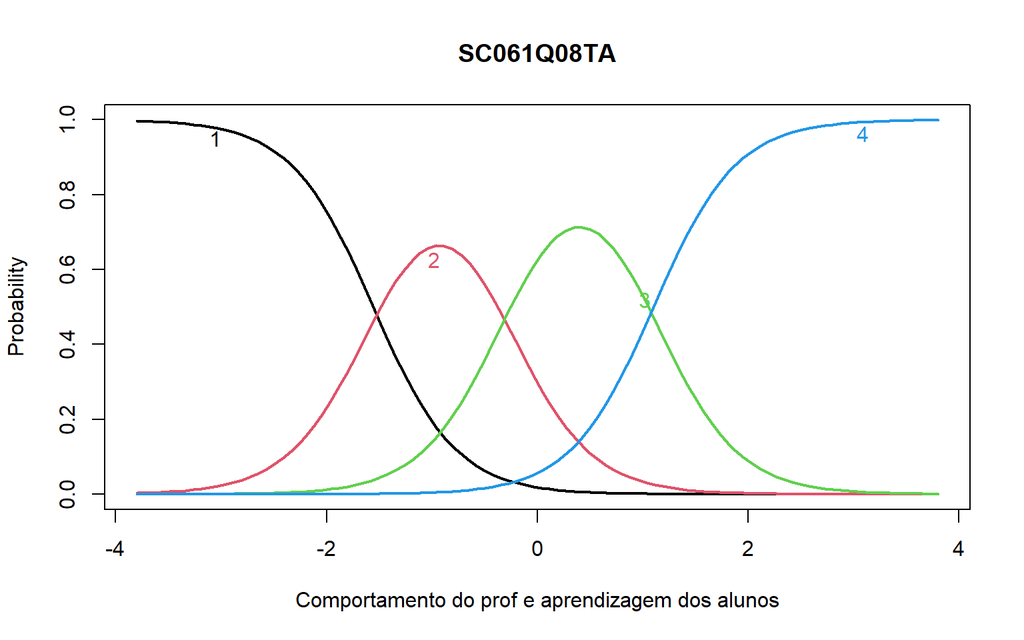

```r
#dev.off()

#png(file="figuras/TRI/CompProf_SC061Q08TA.png", width=600, height=350)
plot(modComprof, item=3,lwd = 2,main = "SC061Q08TA", xlab="Comportamento do prof e aprendizagem dos alunos",ylab="Probability")
```

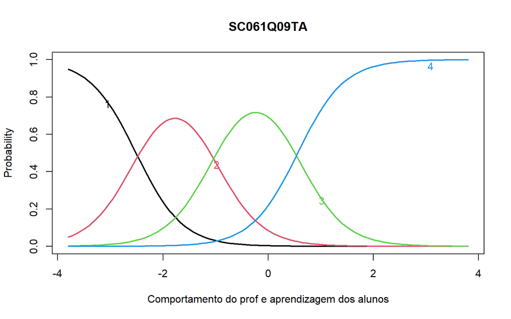

```r
#dev.off()

#png(file="figuras/TRI/CompProf_SC061Q09TA.png", width=600, height=350)
plot(modComprof, item=4,lwd = 2,main = "SC061Q09TA", xlab="Comportamento do prof e aprendizagem dos alunos",ylab="Probability")
```

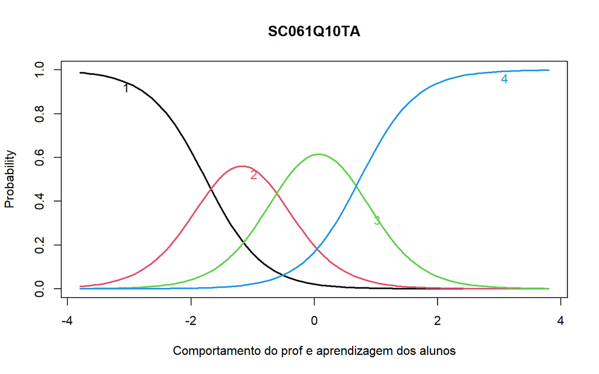

```r
#dev.off()

#png(file="figuras/TRI/CompProf_SC061Q10TA.png", width=600, height=350)
plot(modComprof, item=5,lwd = 2,main = "SC061Q10TA", xlab="Comportamento do prof e aprendizagem dos alunos",ylab="Probability")
```

```r
#dev.off()
```

O codigo abaixo inclui a variavel de Comportamento do professor e aprendizagem dos alunos no banco de dados final, df_pisa.

```r
df_pisa = EscComprof$score.dat %>%
  dplyr::select(-Obs, -Exp, -se.z1) %>%
  mutate_at(vars(starts_with("ST")), factor) %>%
  mutate_at(vars(starts_with("PA")), factor) %>%
  mutate_at(vars(starts_with("SC")), factor)%>%
  rename("Comportamento professor" = z1) %>%
  mutate(Comportamento_professor_Z = scale(`Comportamento professor`)[,1]) %>%
  right_join(df_pisa)
```

## Cooperação

Selecionando apenas as variáveis de cooperação.

```r
coop = df_pisa %>%
  dplyr::select(ST206Q01HA,ST206Q02HA,ST206Q04HA)

#ST206Q03HA - Não funcionou com esta variável (deu erro) porque provavelmente ela tem uma correlação muito baixa com as demais, atrapalhando as estimações.

corcoop = hetcor(coop)

#Matrix de correlacao policorica do cooperação
corcoop = corcoop$correlations
```

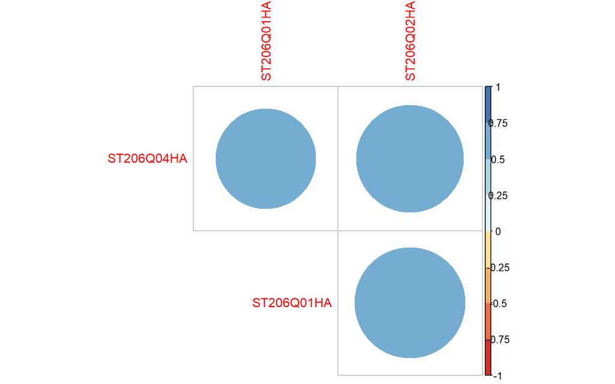

```r
#png(file="figuras/cor_policoricas/Coop.png", width=600, height=350)


corrplot(corcoop, type="upper", order="hclust",
         col=brewer.pal(n=8, name="RdYlBu"), diag = F)
```

```r
#dev.off()
```

```r
data.pcacoop <- princomp(corcoop)
summary(data.pcacoop)
```

```
## Importance of components:
##                           Comp.1    Comp.2 Comp.3
## Standard deviation     0.2378457 0.1513132      0
## Proportion of Variance 0.7118818 0.2881182      0
## Cumulative Proportion  0.7118818 1.0000000      1
```

```r
eigen(corcoop)
```

```
## eigen() decomposition
## $values
## [1] 2.3326368 0.4108937 0.2564695
##
## $vectors
##            [,1]       [,2]       [,3]
## [1,] -0.5732983 -0.6292986  0.5247021
## [2,] -0.5975857 -0.1169757 -0.7932263
## [3,] -0.5605536  0.7683098  0.3089979
```

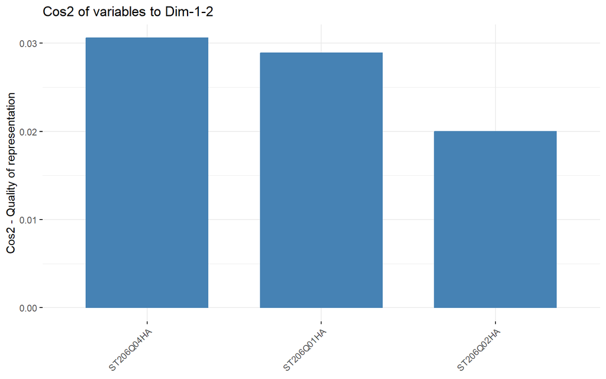

```r
#png(file="figuras/PCA/Coop1.png", width=600, height=350)

fviz_cos2(data.pcacoop , choice = "var", axes = 1:2)
```

```r
#dev.off()
```

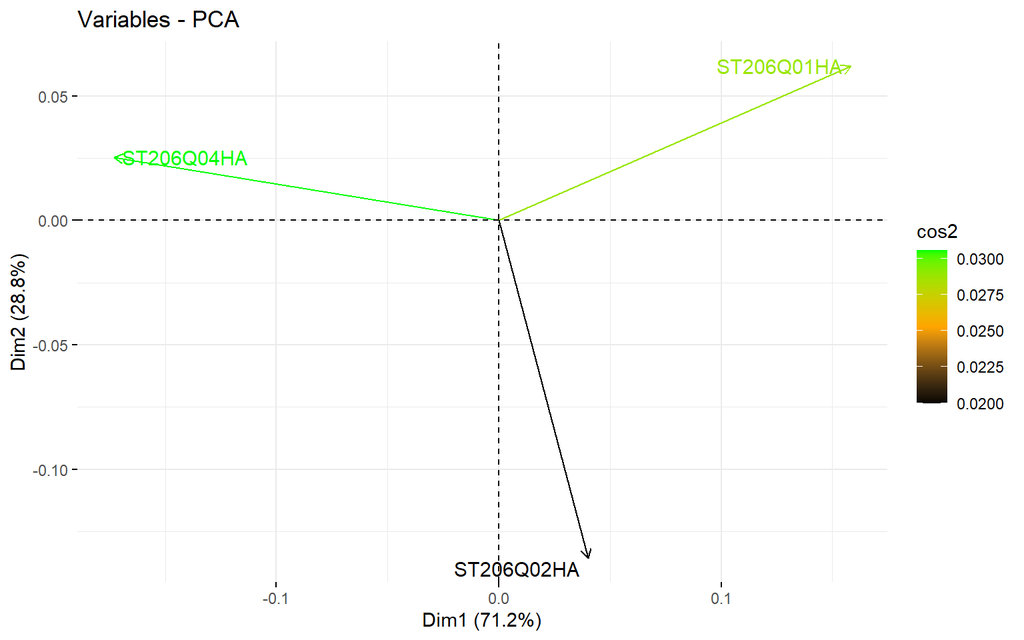

```r
#png(file="figuras/PCA/Coop2.png", width=600, height=350)

fviz_pca_var(data.pcacoop, col.var = "cos2",
            gradient.cols = c("black", "orange", "green"),
            repel = TRUE)
```

```r
#dev.off()
```

```r
data.pcacoop$scores
```

```
##                 Comp.1     Comp.2                     Comp.3
## ST206Q01HA  0.25892997  0.1365888  0.00000000000000018041124
## ST206Q02HA  0.05647141 -0.2109518 -0.00000000000000027061686
## ST206Q04HA -0.31540138  0.0743630  0.00000000000000002775558
```

```r
modCoop = grm(coop)
coef(modCoop)
```

```
##            Extrmt1 Extrmt2 Extrmt3 Dscrmn
## ST206Q01HA  -1.264   0.013   1.914  2.581
## ST206Q02HA  -1.242   0.010   1.799  3.808
## ST206Q04HA  -1.411  -0.070   1.781  2.280
```

```r
EscCoop = factor.scores(modCoop)
```

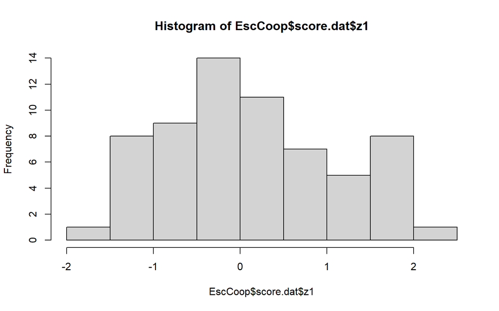

```r
hist(EscCoop$score.dat$z1)
```

```r
names(modCoop)
```

```
##  [1] "coefficients" "log.Lik"      "convergence"  "hessian"      "counts"
##  [6] "patterns"     "GH"           "max.sc"       "constrained"  "IRT.param"
## [11] "X"            "control"      "na.action"    "call"
```

```r
summary(modCoop)
```

```
##
## Call:
## grm(data = coop)
##
## Model Summary:
##    log.Lik      AIC      BIC
##  -31602.36 63228.71 63316.04
##
## Coefficients:
## $ST206Q01HA
##          value
## Extrmt1 -1.264
## Extrmt2  0.013
## Extrmt3  1.914
## Dscrmn   2.581
##
## $ST206Q02HA
##          value
## Extrmt1 -1.242
## Extrmt2  0.010
## Extrmt3  1.799
## Dscrmn   3.808
##
## $ST206Q04HA
##          value
## Extrmt1 -1.411
## Extrmt2 -0.070
## Extrmt3  1.781
## Dscrmn   2.280
##
##
## Integration:
## method: Gauss-Hermite
## quadrature points: 21
##
## Optimization:
## Convergence: 0
## max(|grad|): 49
## quasi-Newton: BFGS
```

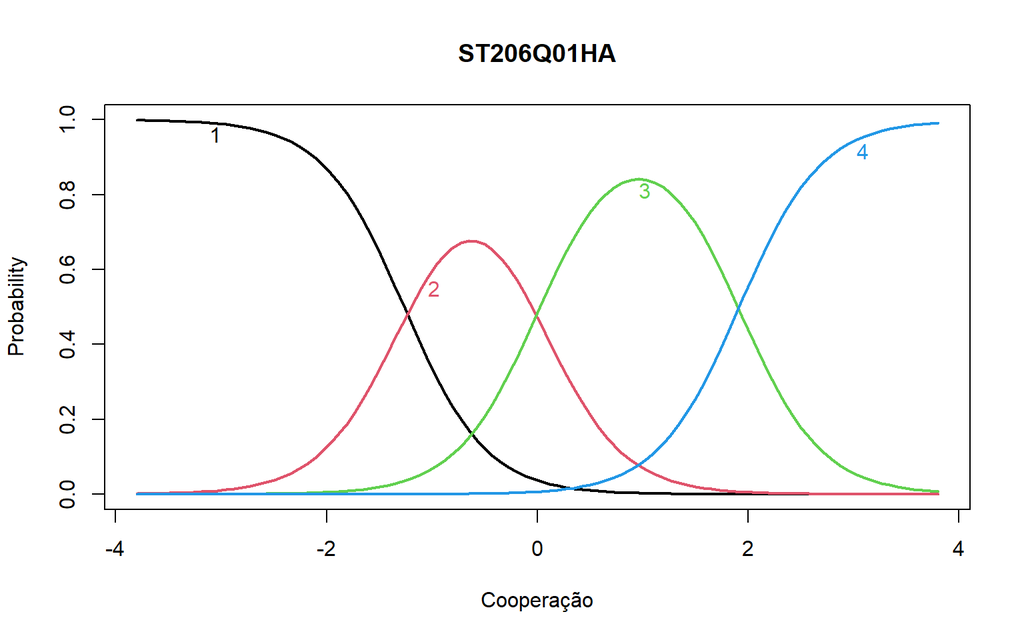

```r
#png(file="figuras/TRI/Coop_ST206Q01HA.png", width=600, height=350)
plot(modCoop, item=1,lwd = 2,main = "ST206Q01HA", xlab="Cooperação",ylab="Probability")
```

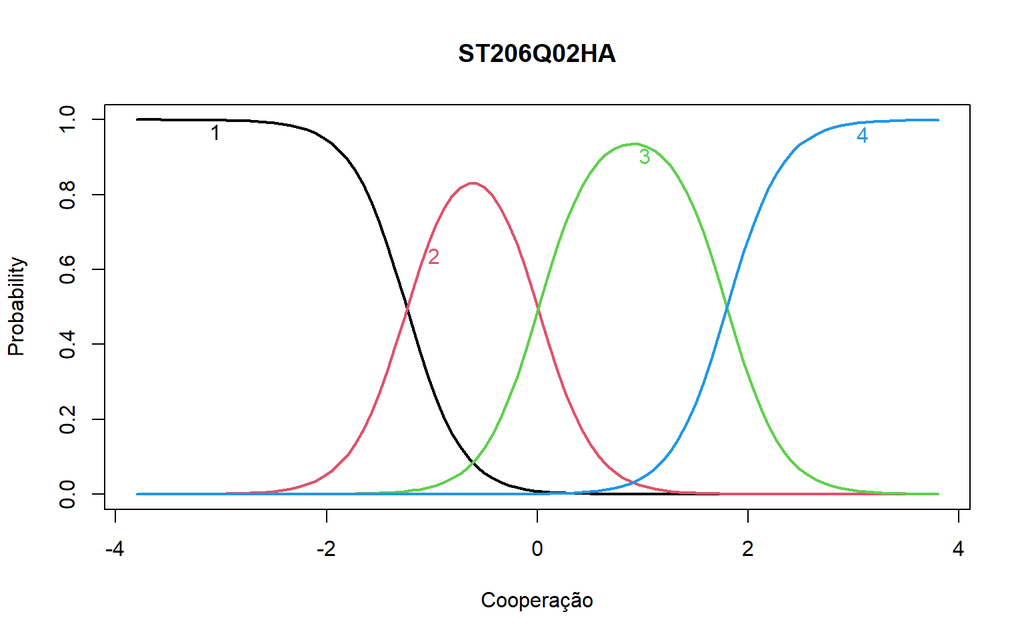

```r
#dev.off()

#png(file="figuras/TRI/Coop_ST206Q02HA.png", width=600, height=350)
plot(modCoop, item=2,lwd = 2,main = "ST206Q02HA", xlab="Cooperação",ylab="Probability")
```

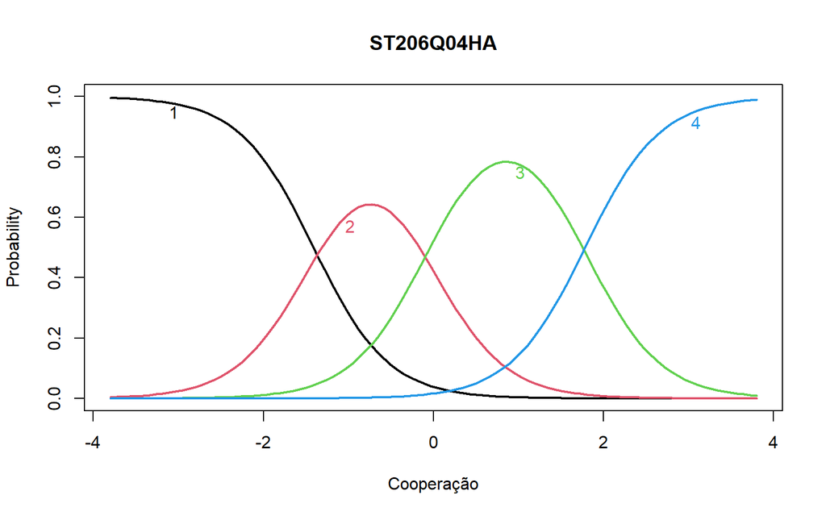

```r
#dev.off()

#png(file="figuras/TRI/Coop_ST206Q04HA.png", width=600, height=350)
plot(modCoop, item=3,lwd = 2,main = "ST206Q04HA", xlab="Cooperação",ylab="Probability")
```

```r
#dev.off()

#plot(modCoop, item=4,lwd = 2,main = "SC061Q09TA", xlab="Cooperação",ylab="Probability")
```

```r
df_pisa = EscCoop$score.dat %>%
  dplyr::select(-Obs, -Exp, -se.z1) %>%
  mutate_at(vars(starts_with("ST")), factor) %>%
  mutate_at(vars(starts_with("PA")), factor) %>%
  mutate_at(vars(starts_with("SC")), factor)%>%
  rename("Cooperação e competição" = z1) %>%
  mutate(Cooperacao_competicao_Z = scale(`Cooperação e competição`)[,1]) %>%
  right_join(df_pisa)
```

## Competição

Selecionando apenas as variáveis de competição.

```r
compet = df_pisa %>%
  dplyr::select(ST205Q01HA,ST205Q02HA,ST205Q03HA,ST205Q04HA)

corcompet = hetcor(compet)

#Matrix de correlacao policorica do comportamento do prof e aprendizagem dos alunos
corcompet = corcompet$correlations
```

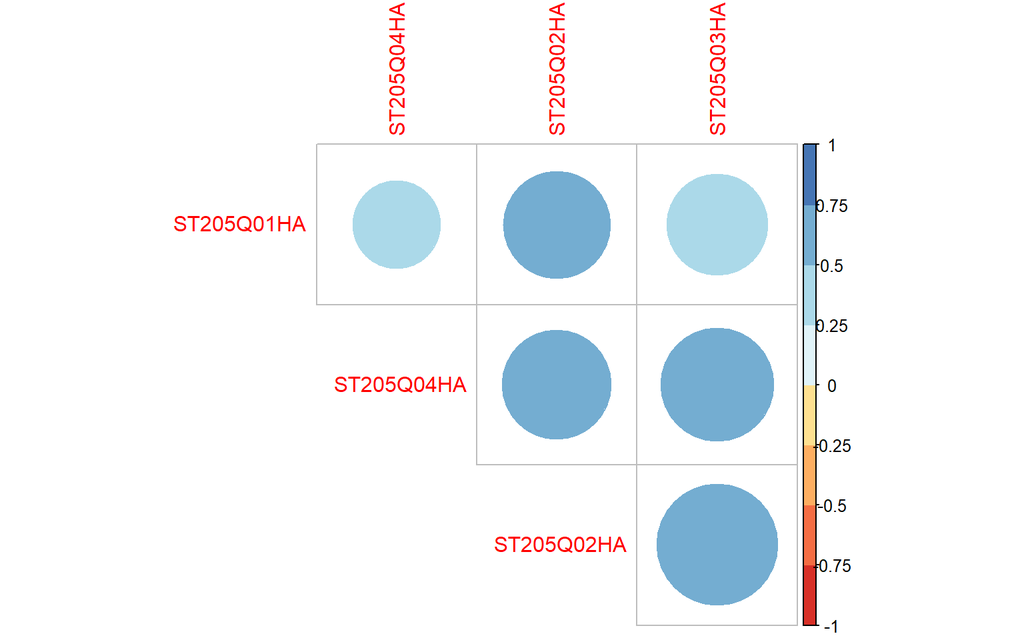

```r
#png(file="figuras/cor_policoricas/Compet.png", width=600, height=350)


corrplot(corcompet, type="upper", order="hclust",
         col=brewer.pal(n=8, name="RdYlBu"), diag = F)
```

```r
#dev.off()
```

```r
data.pcacompet <- princomp(corcompet)
summary(data.pcacompet)
```

```
## Importance of components:
##                           Comp.1    Comp.2    Comp.3                    Comp.4
## Standard deviation     0.3263317 0.2153540 0.1440369 0.00000000274520067953953
## Proportion of Variance 0.6133776 0.2671254 0.1194970 0.00000000000000004340679
## Cumulative Proportion  0.6133776 0.8805030 1.0000000 0.99999999999999988897770
```

```r
eigen(corcompet)
```

```
## eigen() decomposition
## $values
## [1] 2.6756675 0.6435616 0.3931091 0.2876618
##
## $vectors
##            [,1]        [,2]       [,3]       [,4]
## [1,] -0.4428267  0.80067190 -0.3883411 -0.1096368
## [2,] -0.5372472  0.02491626  0.4655691  0.7028442
## [3,] -0.5338420 -0.17454898  0.4456634 -0.6970864
## [4,] -0.4798777 -0.57256995 -0.6586507  0.0897792
```

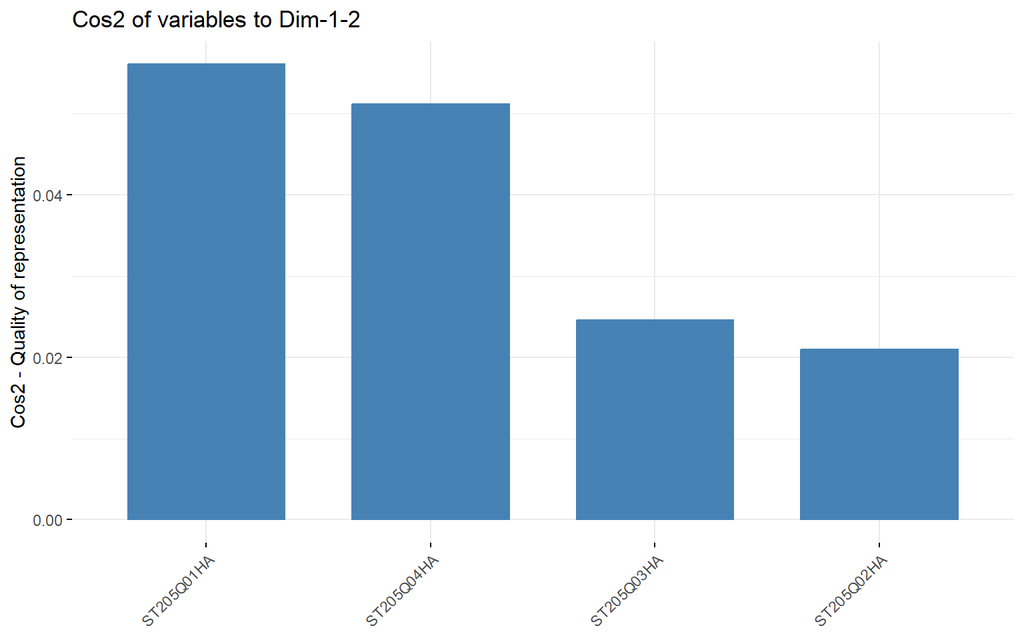

```r
#png(file="figuras/PCA/Compet1.png", width=600, height=350)

fviz_cos2(data.pcacompet , choice = "var", axes = 1:2)
```

```r
#dev.off()
```

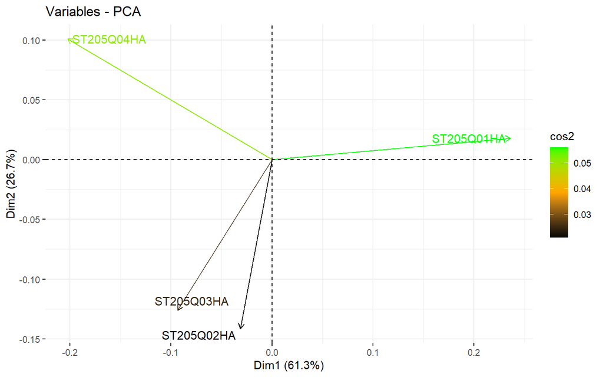

```r
#png(file="figuras/PCA/Compet2.png", width=600, height=350)

fviz_pca_var(data.pcacompet, col.var = "cos2",
            gradient.cols = c("black", "orange", "green"),
            repel = TRUE)
```

```r
#dev.off()
```

```r
data.pcacompet$scores
```

```
##                 Comp.1     Comp.2      Comp.3                     Comp.4
## ST205Q01HA  0.52718423  0.1285690  0.02647343  0.00000000000000002775558
## ST205Q02HA -0.02493657 -0.2246626 -0.19884625 -0.00000000000000008326673
## ST205Q03HA -0.14792980 -0.1905838  0.20427466 -0.00000000000000003295975
## ST205Q04HA -0.35431786  0.2866773 -0.03190184 -0.00000000000000002775558
```

```r
modCompet = grm(compet)
coef(modCompet)
```

```
##            Extrmt1 Extrmt2 Extrmt3 Dscrmn
## ST205Q01HA  -1.772  -0.227   1.989  1.505
## ST205Q02HA  -1.295  -0.216   1.316  3.117
## ST205Q03HA  -1.210  -0.136   1.396  3.106
## ST205Q04HA  -1.504  -0.347   1.290  1.888
```

```r
EscCompet = factor.scores(modCompet)
```

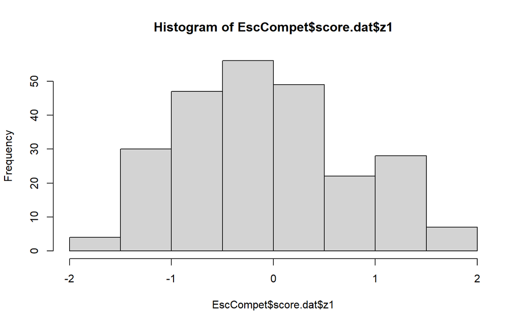

```r
hist(EscCompet$score.dat$z1)
```

```r
names(modCompet)
```

```
##  [1] "coefficients" "log.Lik"      "convergence"  "hessian"      "counts"
##  [6] "patterns"     "GH"           "max.sc"       "constrained"  "IRT.param"
## [11] "X"            "control"      "na.action"    "call"
```

```r
summary(modCompet)
```

```
##
## Call:
## grm(data = compet)
##
## Model Summary:
##   log.Lik     AIC      BIC
##  -45707.9 91447.8 91564.24
##
## Coefficients:
## $ST205Q01HA
##          value
## Extrmt1 -1.772
## Extrmt2 -0.227
## Extrmt3  1.989
## Dscrmn   1.505
##
## $ST205Q02HA
##          value
## Extrmt1 -1.295
## Extrmt2 -0.216
## Extrmt3  1.316
## Dscrmn   3.117
##
## $ST205Q03HA
##          value
## Extrmt1 -1.210
## Extrmt2 -0.136
## Extrmt3  1.396
## Dscrmn   3.106
##
## $ST205Q04HA
##          value
## Extrmt1 -1.504
## Extrmt2 -0.347
## Extrmt3  1.290
## Dscrmn   1.888
##
##
## Integration:
## method: Gauss-Hermite
## quadrature points: 21
##
## Optimization:
## Convergence: 0
## max(|grad|): 0.85
## quasi-Newton: BFGS
```

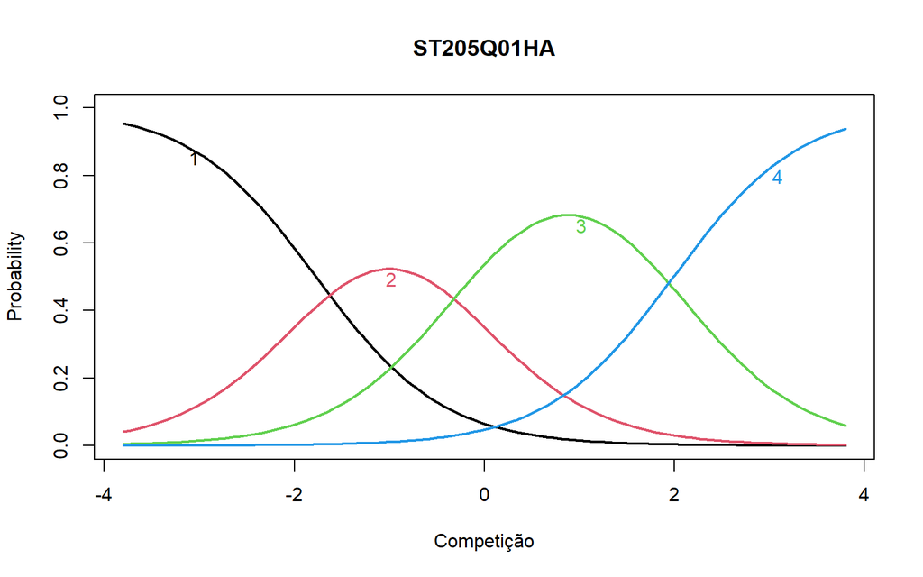

```r
#png(file="figuras/TRI/Compet_ST205Q01HA.png", width=600, height=350)
plot(modCompet, item=1,lwd = 2,main = "ST205Q01HA", xlab="Competição",ylab="Probability")
```

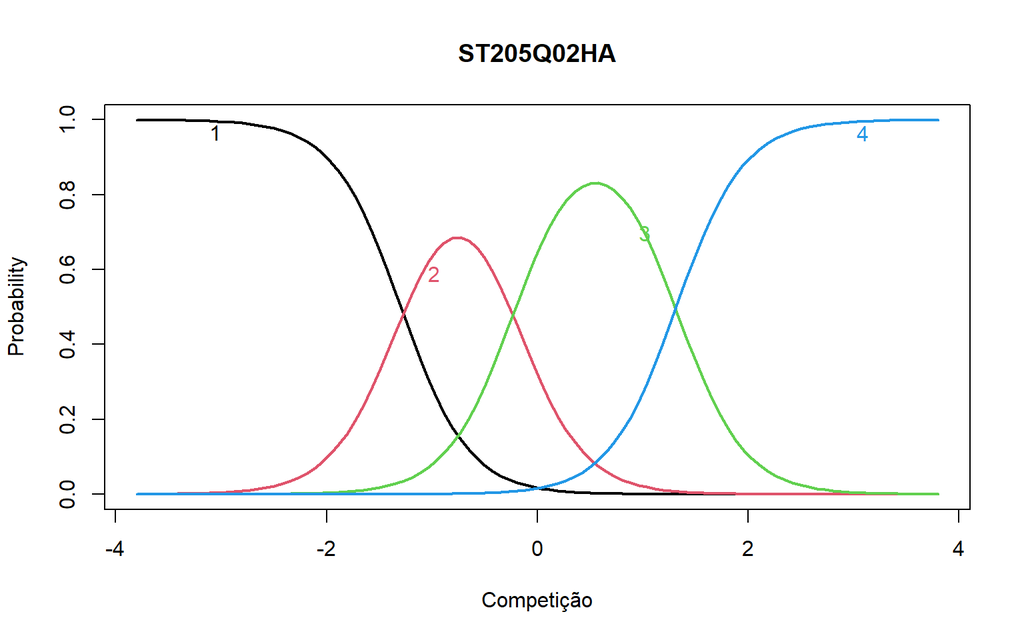

```r
#dev.off()

#png(file="figuras/TRI/Compet_ST205Q02HA.png", width=600, height=350)
plot(modCompet, item=2,lwd = 2,main = "ST205Q02HA", xlab="Competição",ylab="Probability")
```

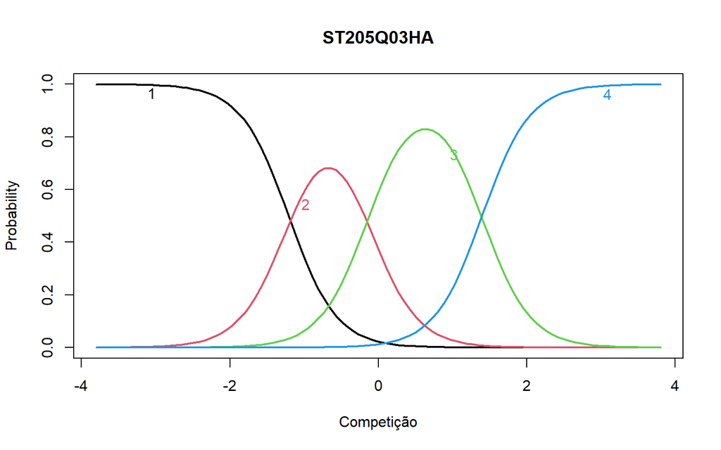

```r
#dev.off()

#png(file="figuras/TRI/Compet_ST205Q03HA.png", width=600, height=350)
plot(modCompet, item=3,lwd = 2,main = "ST205Q03HA", xlab="Competição",ylab="Probability")
```

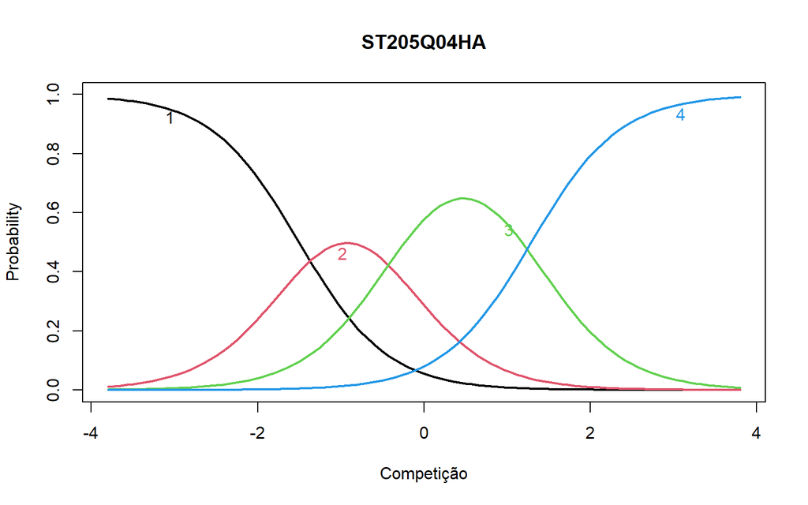

```r
#dev.off()

#png(file="figuras/TRI/Compet_ST205Q04HA.png", width=600, height=350)
plot(modCompet, item=4,lwd = 2,main = "ST205Q04HA", xlab="Competição",ylab="Probability")
```

```r
#dev.off()
```

O codigo abaixo inclui a variavel de Competição no banco de dados final, df_pisa.

```r
df_pisa = EscCompet$score.dat %>%
  dplyr::select(-Obs, -Exp, -se.z1)%>%
  mutate_at(vars(starts_with("ST")), factor) %>%
  mutate_at(vars(starts_with("PA")), factor) %>%
  mutate_at(vars(starts_with("SC")), factor) %>%
  rename("Competição" = z1) %>%
  mutate(Competicao_Z = scale(`Competição`)[,1]) %>%
  right_join(df_pisa)
```

## Sentimento de pertencimento

Selecionando apenas as variáveis de Sentimento de pertencimento.

```r
sent = df_pisa %>%
  dplyr::select(ST034Q01TA,ST034Q02TA,ST034Q03TA,ST034Q04TA,ST034Q05TA,ST034Q06TA)

corsent = hetcor(sent)

#Matrix de correlacao policorica de sentimento de pertencimento
corsent = corsent$correlations
```

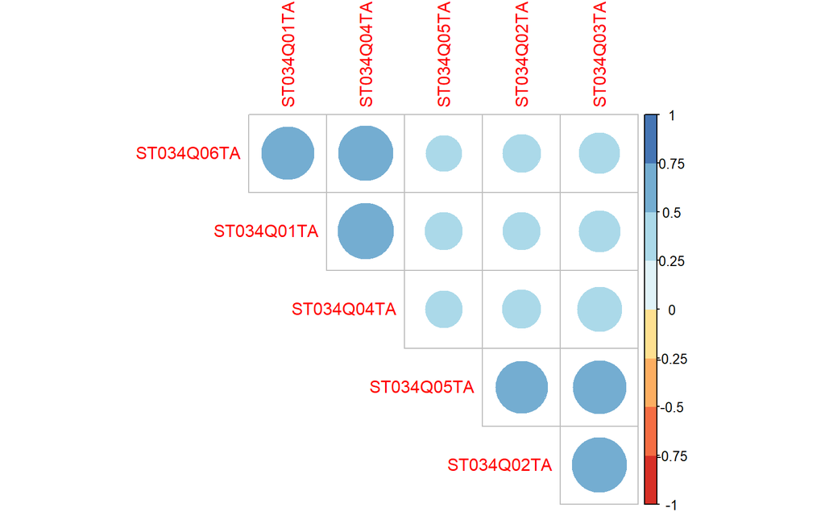

```r
#png(file="figuras/cor_policoricas/sent_pert.png", width=600, height=350)


corrplot(corsent, type="upper", order="hclust",
         col=brewer.pal(n=8, name="RdYlBu"), diag = F)
```

```r
#dev.off()
```

```r
data.pcasent <- princomp(corsent)
summary(data.pcasent)
```

```
## Importance of components:
##                           Comp.1     Comp.2    Comp.3     Comp.4     Comp.5
## Standard deviation     0.5121801 0.18774458 0.1791510 0.16523290 0.13601934
## Proportion of Variance 0.6986581 0.09387588 0.0854787 0.07271304 0.04927431
## Cumulative Proportion  0.6986581 0.79253395 0.8780126 0.95072569 1.00000000
##                        Comp.6
## Standard deviation          0
## Proportion of Variance      0
## Cumulative Proportion       1
```

```r
eigen(corsent)
```

```
## eigen() decomposition
## $values
## [1] 3.1254663 1.2535162 0.4576085 0.4300657 0.4001988 0.3331444
##
## $vectors
##            [,1]       [,2]        [,3]        [,4]          [,5]       [,6]
## [1,] -0.4112860  0.4036247 -0.37508467  0.35944278  0.4657210810  0.4256139
## [2,] -0.3960080 -0.4331780  0.51740715  0.09349738  0.5739388178 -0.2228829
## [3,] -0.4278856 -0.3560666  0.16194732  0.34588814 -0.5991654466  0.4304250
## [4,] -0.4280311  0.3937158 -0.02588798  0.26353646 -0.2938267192 -0.7108597
## [5,] -0.3806509 -0.4539931 -0.66230968 -0.43056009  0.0005707773 -0.1579833
## [6,] -0.4035216  0.4019187  0.35503535 -0.69827435 -0.0914571433  0.2315818
```

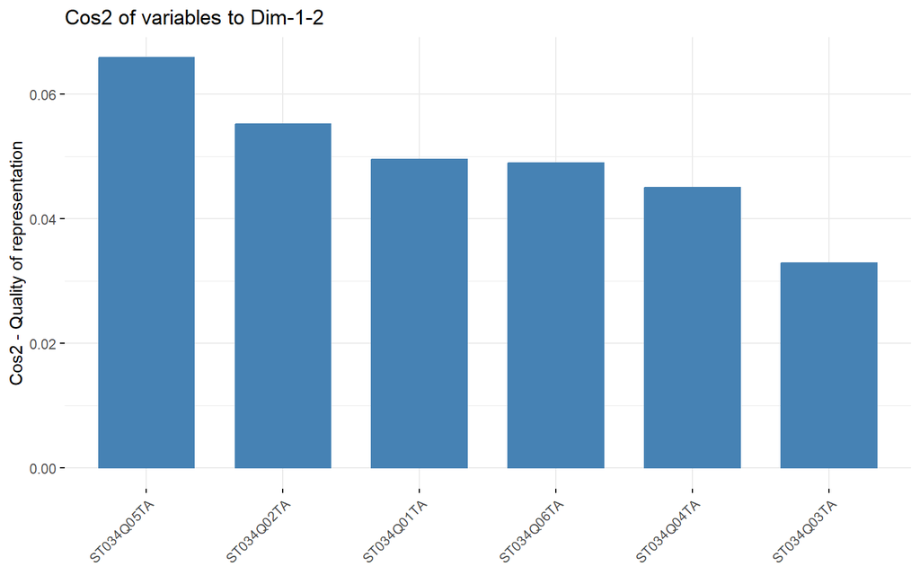

```r
#png(file="figuras/PCA/sent_pert1.png", width=600, height=350)

fviz_cos2(data.pcasent , choice = "var", axes = 1:2)
```

```r
#dev.off()
```

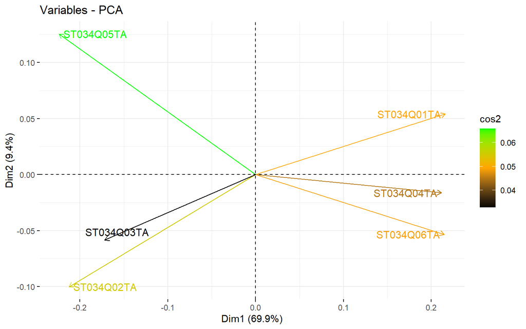

```r
#png(file="figuras/PCA/sent_pert2.png", width=600, height=350)

fviz_pca_var(data.pcasent, col.var = "cos2",
            gradient.cols = c("black", "orange", "green"),
            repel = TRUE)
```

```r
#dev.off()
```

```r
data.pcasent$scores
```

```
##                Comp.1      Comp.2      Comp.3      Comp.4      Comp.5
## ST034Q01TA  0.5150369  0.15282593  0.14975405  0.20433288  0.14254084
## ST034Q02TA -0.5349595 -0.22421638 -0.04626207  0.24090842 -0.07329682
## ST034Q03TA -0.4335012 -0.12692381  0.18951592 -0.21042072  0.14173373
## ST034Q04TA  0.5052392 -0.02238045  0.14094788 -0.09638720 -0.23768148
## ST034Q05TA -0.5634921  0.33045618 -0.12194441 -0.04831925 -0.05137749
## ST034Q06TA  0.5116766 -0.10976147 -0.31201137 -0.09011413  0.07808121
##                                Comp.6
## ST034Q01TA  0.00000000000000004857226
## ST034Q02TA  0.00000000000000000000000
## ST034Q03TA -0.00000000000000001387779
## ST034Q04TA  0.00000000000000006938894
## ST034Q05TA  0.00000000000000012490009
## ST034Q06TA -0.00000000000000002775558
```

```r
modSent = grm(sent)
coef(modSent)
```

```
##            Extrmt1 Extrmt2 Extrmt3 Dscrmn
## ST034Q01TA  -1.845  -0.880   0.887  1.978
## ST034Q02TA  -2.661  -0.983   1.214  1.251
## ST034Q03TA  -2.444  -1.032   1.198  1.575
## ST034Q04TA  -1.963  -1.003   0.627  2.354
## ST034Q05TA  -2.979  -1.406   1.742  1.260
## ST034Q06TA  -2.108  -1.071   0.651  1.892
```

```r
EscSent = factor.scores(modSent)
```

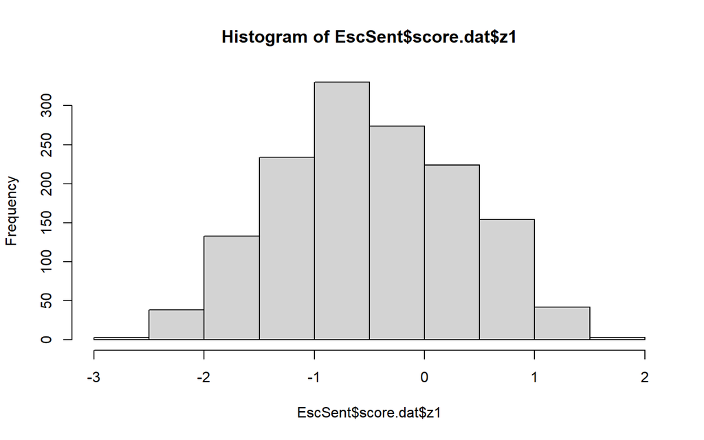

```r
hist(EscSent$score.dat$z1)
```

```r
names(modSent)
```

```
##  [1] "coefficients" "log.Lik"      "convergence"  "hessian"      "counts"
##  [6] "patterns"     "GH"           "max.sc"       "constrained"  "IRT.param"
## [11] "X"            "control"      "na.action"    "call"
```

```r
summary(modSent)
```

```
##
## Call:
## grm(data = sent)
##
## Model Summary:
##    log.Lik      AIC      BIC
##  -65480.81 131009.6 131184.3
##
## Coefficients:
## $ST034Q01TA
##          value
## Extrmt1 -1.845
## Extrmt2 -0.880
## Extrmt3  0.887
## Dscrmn   1.978
##
## $ST034Q02TA
##          value
## Extrmt1 -2.661
## Extrmt2 -0.983
## Extrmt3  1.214
## Dscrmn   1.251
##
## $ST034Q03TA
##          value
## Extrmt1 -2.444
## Extrmt2 -1.032
## Extrmt3  1.198
## Dscrmn   1.575
##
## $ST034Q04TA
##          value
## Extrmt1 -1.963
## Extrmt2 -1.003
## Extrmt3  0.627
## Dscrmn   2.354
##
## $ST034Q05TA
##          value
## Extrmt1 -2.979
## Extrmt2 -1.406
## Extrmt3  1.742
## Dscrmn   1.260
##
## $ST034Q06TA
##          value
## Extrmt1 -2.108
## Extrmt2 -1.071
## Extrmt3  0.651
## Dscrmn   1.892
##
##
## Integration:
## method: Gauss-Hermite
## quadrature points: 21
##
## Optimization:
## Convergence: 0
## max(|grad|): 0.65
## quasi-Newton: BFGS
```

[figure not shown]

```r
#png(file="figuras/TRI/sent_pert_ST034Q01TA.png", width=600, height=350)
plot(modApoio, item=1,lwd = 2,main = "ST034Q01TA", xlab="Sentimento de pertencimento",ylab="Probability")
```

[figure not shown]

```r
#dev.off()

#png(file="figuras/TRI/sent_pert_ST034Q02TA.png", width=600, height=350)
plot(modApoio, item=2,lwd = 2,main = "ST034Q02TA", xlab="Sentimento de pertencimento",ylab="Probability")
```

[figure not shown]

```r
#dev.off()

#png(file="figuras/TRI/sent_pert_ST034Q03TA.png", width=600, height=350)
plot(modApoio, item=3,lwd = 2,main = "ST034Q03TA", xlab="Sentimento de pertencimento",ylab="Probability")
```

[figure not shown]

```r
#dev.off()

#png(file="figuras/TRI/sent_pert_ST034Q04TA.png", width=600, height=350)
plot(modApoio, item=4,lwd = 2,main = "ST034Q04TA", xlab="Sentimento de pertencimento",ylab="Probability")
```

[figure not shown]

```r
#dev.off()

#png(file="figuras/TRI/sent_pert_ST034Q05TA.png", width=600, height=350)
plot(modApoio, item=5,lwd = 2,main = "ST034Q05TA", xlab="Sentimento de pertencimento",ylab="Probability")
```

[figure not shown]

```r
#dev.off()

#png(file="figuras/TRI/sent_pert_ST034Q06TA.png", width=600, height=350)
plot(modApoio, item=6,lwd = 2,main = "ST034Q06TA", xlab="Sentimento de pertencimento",ylab="Probability")
```

```r
#dev.off()
```

O codigo abaixo inclui a variavel de Sentimento de pertencimento no banco de dados final, df_pisa.

```r
df_pisa = EscSent$score.dat %>%
  dplyr::select(-Obs, -Exp, -se.z1) %>%
  mutate_at(vars(starts_with("ST")), factor) %>%
  mutate_at(vars(starts_with("PA")), factor) %>%
  mutate_at(vars(starts_with("SC")), factor)%>%
  rename("Sentimento de pertencimento" = z1) %>%
  mutate(Sentimento_pertencimento_Z = scale(`Sentimento de pertencimento`)[,1]) %>%
  right_join(df_pisa)
```

## Envolvimento dos pais 1

Selecionando apenas as variáveis de envolvimento dos pais.

```r
#SC064Q01TA,SC064Q02TA,SC064Q03TA, SC064Q04NA

Envpais = df_pisa %>%
  dplyr::select(PA008Q01TA,PA008Q02TA,PA008Q03TA,PA008Q04TA,PA008Q05TA,PA008Q06NA,PA008Q07NA,PA008Q08NA,PA008Q09NA,PA008Q10NA)

corenvpais= hetcor(Envpais)

#Matrix de correlacao policorica de envolvimento dos pais
corenvpais = corenvpais$correlations
```

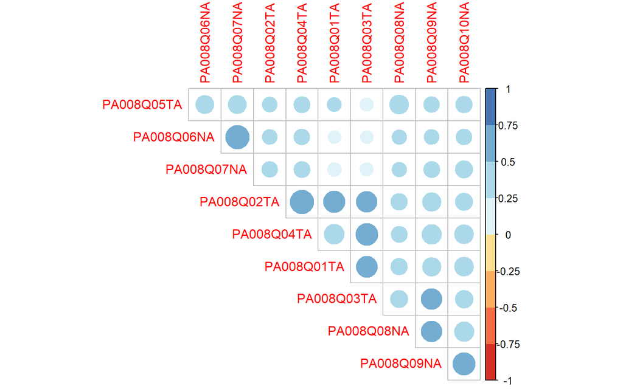

```r
#png(file="figuras/cor_policoricas/envpais.png", width=600, height=350)


corrplot(corenvpais, type="upper", order="hclust",
         col=brewer.pal(n=8, name="RdYlBu"), diag = F)
```

```r
#dev.off()
```

```r
data.pcaenvpais <- princomp(corenvpais)
summary(data.pcaenvpais)
```

```
## Importance of components:
##                           Comp.1    Comp.2    Comp.3     Comp.4     Comp.5
## Standard deviation     0.4598664 0.3014078 0.2245303 0.17507645 0.16695897
## Proportion of Variance 0.4598489 0.1975425 0.1096230 0.06665108 0.06061376
## Cumulative Proportion  0.4598489 0.6573914 0.7670143 0.83366540 0.89427916
##                            Comp.6     Comp.7     Comp.8     Comp.9
## Standard deviation     0.13997648 0.11073061 0.09846657 0.08407719
## Proportion of Variance 0.04260512 0.02666165 0.02108285 0.01537121
## Cumulative Proportion  0.93688429 0.96354594 0.98462879 1.00000000
##                                          Comp.10
## Standard deviation     0.00000000299242270481699
## Proportion of Variance 0.00000000000000001947142
## Cumulative Proportion  1.00000000000000000000000
```

```r
eigen(corenvpais)
```

```
## eigen() decomposition
## $values
##  [1] 4.5269151 1.3984645 0.9530661 0.7009548 0.5457776 0.5096987 0.4420274
##  [8] 0.3488079 0.3112496 0.2630383
##
## $vectors
##             [,1]        [,2]       [,3]          [,4]         [,5]        [,6]
##  [1,] -0.3207707 -0.28520359  0.1422960 -0.0003761637  0.710533422 -0.44293413
##  [2,] -0.3436788 -0.22867561  0.3648992 -0.2133908504 -0.009876405  0.23175737
##  [3,] -0.3315565 -0.33099574  0.1205181  0.0171290510 -0.363507952 -0.41555718
##  [4,] -0.3553479 -0.19175702  0.3181098 -0.1639879758 -0.250455186  0.44592806
##  [5,] -0.2680079  0.35401280 -0.2211749 -0.6723123535  0.218807514  0.16187480
##  [6,] -0.2623911  0.54902612  0.2690862  0.1667804936 -0.095537349 -0.23704758
##  [7,] -0.2785075  0.52559939  0.2425342  0.2463252670 -0.022292665 -0.06001284
##  [8,] -0.3024826  0.03376764 -0.5659410 -0.2552420248 -0.242858667 -0.29565448
##  [9,] -0.3491282 -0.12554541 -0.3454774  0.3511845398 -0.246063693  0.04733820
## [10,] -0.3334054 -0.01122877 -0.3333010  0.4453132603  0.350927533  0.45045449
##              [,7]        [,8]           [,9]       [,10]
##  [1,] -0.04634387  0.05453378  0.05219773842 -0.29431636
##  [2,] -0.47537870  0.30927534 -0.06617268244  0.52065461
##  [3,]  0.51423477 -0.24852389 -0.15133399354  0.33431242
##  [4,]  0.03931511 -0.29249508  0.12883583340 -0.58616879
##  [5,]  0.43762066  0.16811276 -0.00001380097  0.08983604
##  [6,] -0.06959774 -0.08502811  0.66115383121  0.12239739
##  [7,] -0.04840098  0.05140333 -0.70151338280 -0.15961007
##  [8,] -0.53357877 -0.27700973 -0.06827494728 -0.09712007
##  [9,]  0.13258589  0.69327585  0.13897057783 -0.19837119
## [10,]  0.07000425 -0.39819286  0.01327470333  0.29937863
```

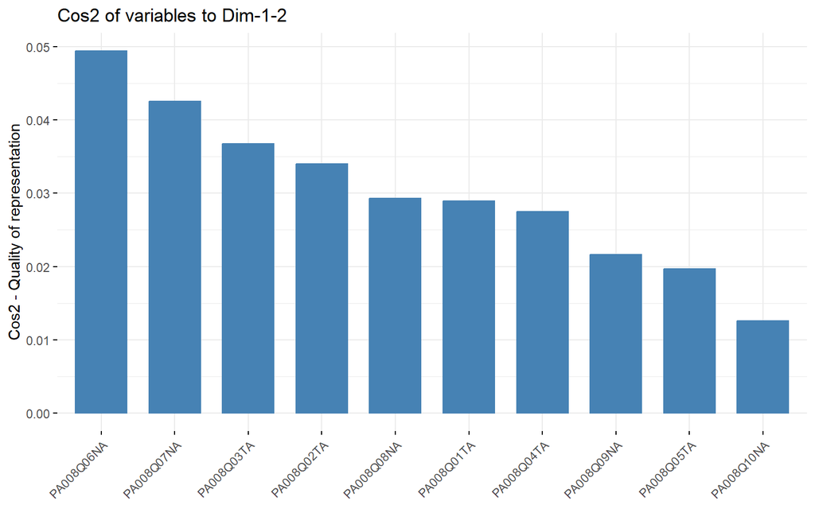

```r
#png(file="figuras/PCA/envpais1.png", width=600, height=350)

fviz_cos2(data.pcaenvpais , choice = "var", axes = 1:2)
```

```r
#dev.off()
```

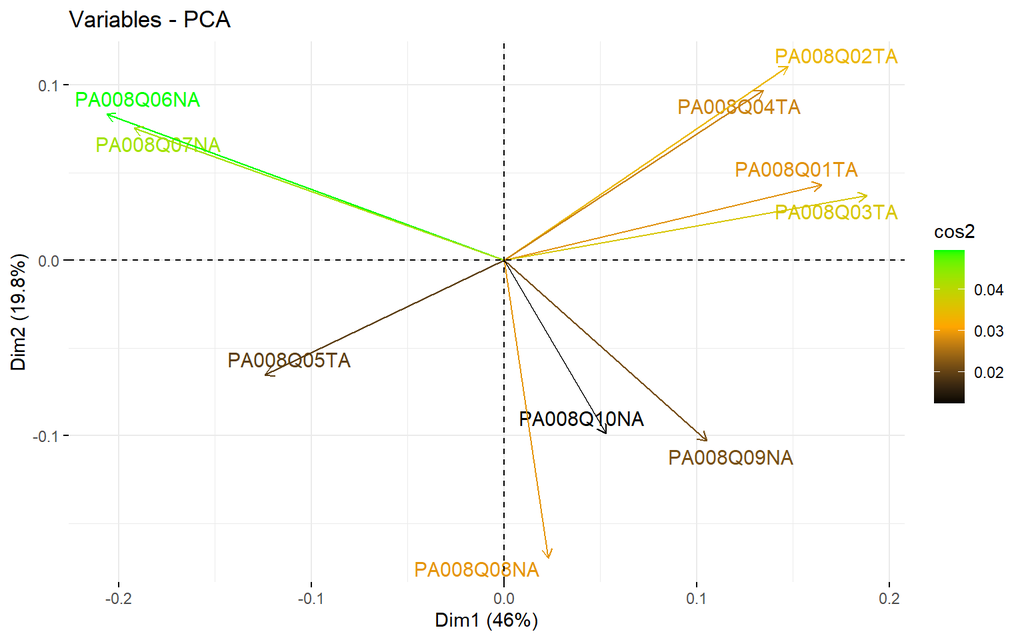

```r
#png(file="figuras/PCA/envpais2.png", width=600, height=350)

fviz_pca_var(data.pcaenvpais, col.var = "cos2",
            gradient.cols = c("black", "orange", "green"),
            repel = TRUE)
```

```r
#dev.off()
```

```r
data.pcaenvpais$scores
```

```
##                 Comp.1     Comp.2      Comp.3        Comp.4      Comp.5
## PA008Q01TA  0.42416961  0.1334108  0.04172970  0.4516381070  0.06057620
## PA008Q02TA  0.38386768  0.3477619  0.13621067 -0.0692297208 -0.12422784
## PA008Q03TA  0.50238024  0.1132108  0.01018375 -0.0790495094  0.29447096
## PA008Q04TA  0.35191686  0.3044122  0.08167127 -0.2331421912 -0.17141975
## PA008Q05TA -0.50259641 -0.2105962  0.46184360  0.0477203491 -0.14477732
## PA008Q06NA -0.76341631  0.2591412 -0.12205405  0.0002789762  0.13201826
## PA008Q07NA -0.70897534  0.2347568 -0.19146289 -0.0061573176  0.02473937
## PA008Q08NA -0.02661254 -0.5395770  0.17894423 -0.0813736060  0.17264817
## PA008Q09NA  0.25610025 -0.3272059 -0.26730841 -0.1331052883  0.02793517
## PA008Q10NA  0.08316596 -0.3153148 -0.32975787  0.1024202010 -0.27196321
##                 Comp.6      Comp.7          Comp.8      Comp.9
## PA008Q01TA  0.03491954  0.02867835  0.013605222052  0.08340467
## PA008Q02TA  0.20578425  0.10075304 -0.016751226654 -0.14258024
## PA008Q03TA -0.22258762 -0.08387054 -0.047735854675 -0.08455557
## PA008Q04TA -0.02701301 -0.10325090  0.037881042231  0.15457082
## PA008Q05TA -0.19188624  0.06204841  0.000007813824 -0.02174943
## PA008Q06NA  0.03493794 -0.02994903  0.205249528742 -0.02708245
## PA008Q07NA  0.02450728  0.02318139 -0.219190149119  0.04088591
## PA008Q08NA  0.24144783 -0.09402535 -0.023112655658  0.02911321
## PA008Q09NA -0.05851116  0.24208470  0.045260121570  0.04773248
## PA008Q10NA -0.04159880 -0.14565007  0.004786157687 -0.07973940
##                                Comp.10
## PA008Q01TA -0.000000000000000032959746
## PA008Q02TA  0.000000000000000284494650
## PA008Q03TA  0.000000000000000225514052
## PA008Q04TA -0.000000000000000001734723
## PA008Q05TA -0.000000000000000284494650
## PA008Q06NA -0.000000000000000215105711
## PA008Q07NA -0.000000000000000385108612
## PA008Q08NA -0.000000000000000285795693
## PA008Q09NA -0.000000000000000124900090
## PA008Q10NA -0.000000000000000027755576
```

```r
modEnvpais = grm(Envpais)
coef(modEnvpais)
```

```
##            Extrmt1 Extrmt2 Dscrmn
## PA008Q01TA  -2.278   0.533  1.674
## PA008Q02TA  -2.054   0.654  2.013
## PA008Q03TA  -2.388   0.537  1.842
## PA008Q04TA  -1.979   0.801  2.243
## PA008Q05TA  -3.183   0.906  0.970
## PA008Q06NA  -2.528   2.547  1.092
## PA008Q07NA  -2.386   2.141  1.146
## PA008Q08NA  -3.032  -1.121  1.283
## PA008Q09NA  -2.716   0.239  1.859
## PA008Q10NA  -2.562   0.533  1.617
```

```r
EscEnvpais = factor.scores(modEnvpais)
```

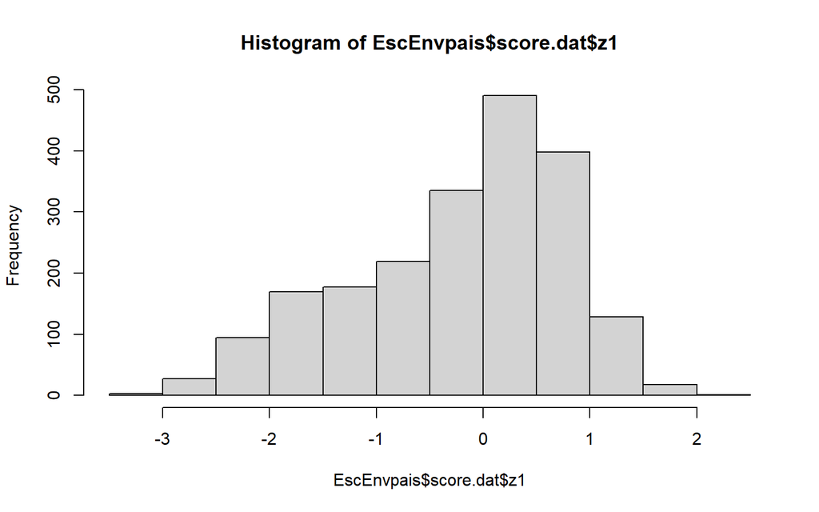

```r
hist(EscEnvpais$score.dat$z1)
```

```r
names(modEnvpais)
```

```
##  [1] "coefficients" "log.Lik"      "convergence"  "hessian"      "counts"
##  [6] "patterns"     "GH"           "max.sc"       "constrained"  "IRT.param"
## [11] "X"            "control"      "na.action"    "call"
```

```r
summary(modEnvpais)
```

```
##
## Call:
## grm(data = Envpais)
##
## Model Summary:
##   log.Lik    AIC      BIC
##  -70878.5 141817 142035.3
##
## Coefficients:
## $PA008Q01TA
##          value
## Extrmt1 -2.278
## Extrmt2  0.533
## Dscrmn   1.674
##
## $PA008Q02TA
##          value
## Extrmt1 -2.054
## Extrmt2  0.654
## Dscrmn   2.013
##
## $PA008Q03TA
##          value
## Extrmt1 -2.388
## Extrmt2  0.537
## Dscrmn   1.842
##
## $PA008Q04TA
##          value
## Extrmt1 -1.979
## Extrmt2  0.801
## Dscrmn   2.243
##
## $PA008Q05TA
##          value
## Extrmt1 -3.183
## Extrmt2  0.906
## Dscrmn   0.970
##
## $PA008Q06NA
```

[output cut: 23 more lines]

```
## $PA008Q10NA
##          value
## Extrmt1 -2.562
## Extrmt2  0.533
## Dscrmn   1.617
##
##
## Integration:
## method: Gauss-Hermite
## quadrature points: 21
##
## Optimization:
## Convergence: 0
## max(|grad|): 0.76
## quasi-Newton: BFGS
```

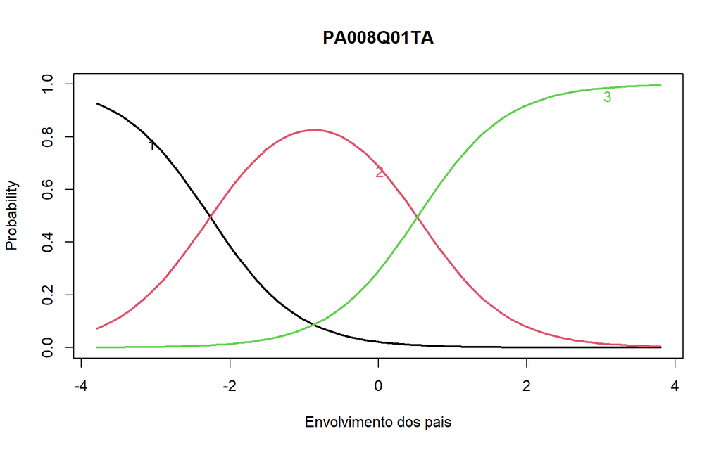

```r
#png(file="figuras/TRI/envpais_PA008Q01TA.png", width=600, height=350)
plot(modEnvpais, item=1,lwd = 2,main = "PA008Q01TA", xlab="Envolvimento dos pais",ylab="Probability")
```

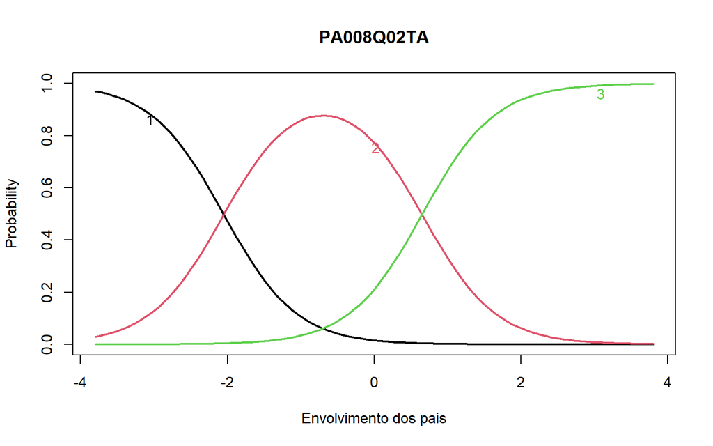

```r
#dev.off()

#png(file="figuras/TRI/envpais_PA008Q02TA.png", width=600, height=350)
plot(modEnvpais, item=2,lwd = 2,main = "PA008Q02TA", xlab="Envolvimento dos pais",ylab="Probability")
```

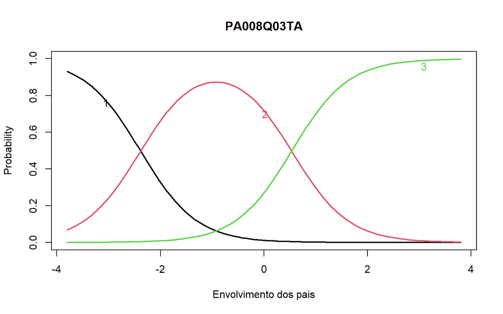

```r
#dev.off()

#png(file="figuras/TRI/envpais_PA008Q03TA.png", width=600, height=350)
plot(modEnvpais, item=3,lwd = 2,main = "PA008Q03TA", xlab="Envolvimento dos pais",ylab="Probability")
```

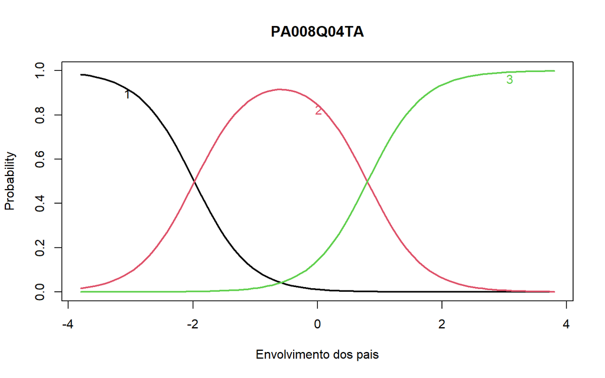

```r
#dev.off()

#png(file="figuras/TRI/envpais_PA008Q04TA.png", width=600, height=350)
plot(modEnvpais, item=4,lwd = 2,main = "PA008Q04TA", xlab="Envolvimento dos pais",ylab="Probability")
```

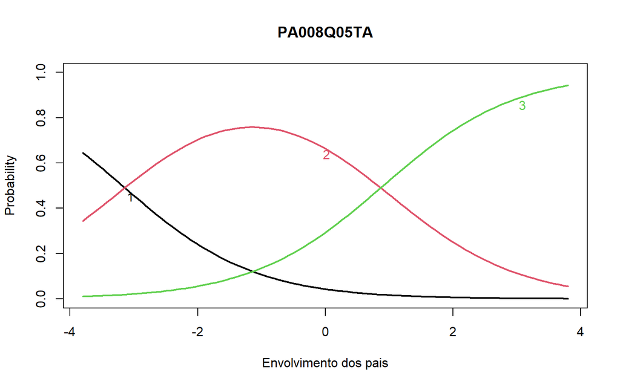

```r
#dev.off()

#png(file="figuras/TRI/envpais_PA008Q05TA.png", width=600, height=350)
plot(modEnvpais, item=5,lwd = 2,main = "PA008Q05TA", xlab="Envolvimento dos pais",ylab="Probability")
```

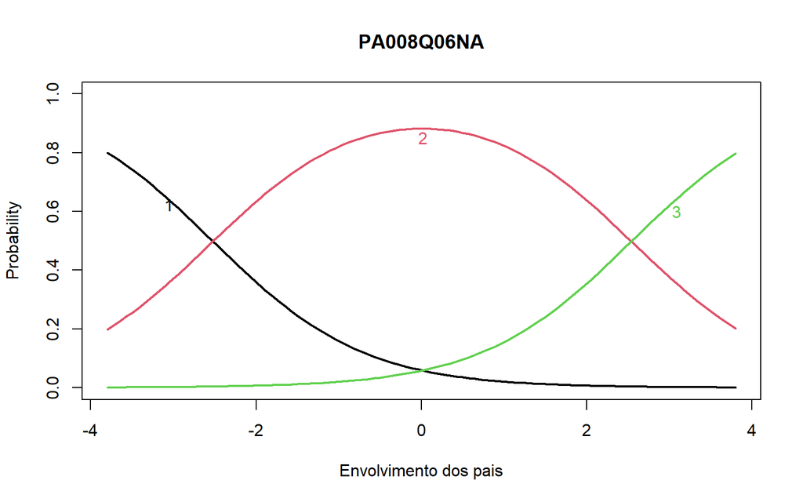

```r
#dev.off()

#png(file="figuras/TRI/envpais_PA008Q06NA.png", width=600, height=350)
plot(modEnvpais, item=6,lwd = 2,main = "PA008Q06NA", xlab="Envolvimento dos pais",ylab="Probability")
```

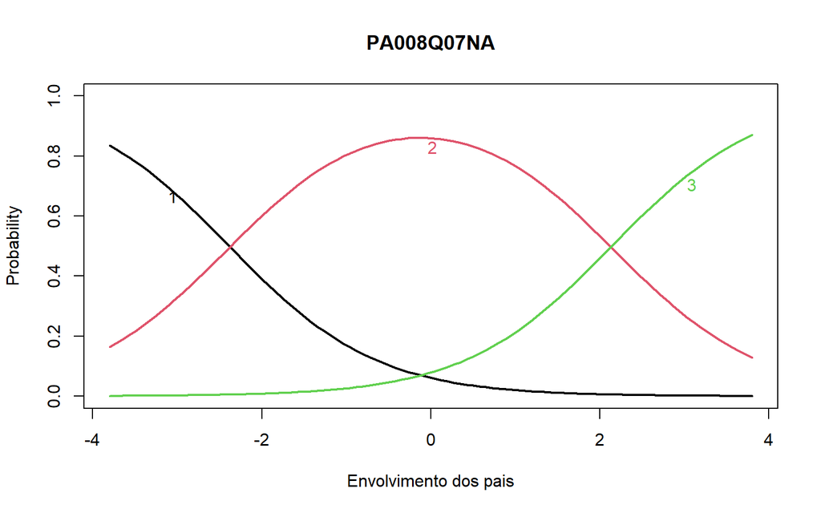

```r
#dev.off()

#png(file="figuras/TRI/envpais_PA008Q07NA.png", width=600, height=350)
plot(modEnvpais, item=7,lwd = 2,main = "PA008Q07NA", xlab="Envolvimento dos pais",ylab="Probability")
```

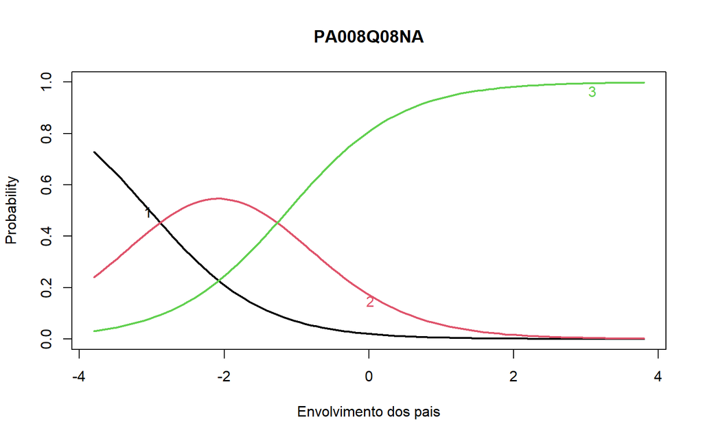

```r
#dev.off()

#png(file="figuras/TRI/envpais_PA008Q08NA.png", width=600, height=350)
plot(modEnvpais, item=8,lwd = 2,main = "PA008Q08NA", xlab="Envolvimento dos pais",ylab="Probability")
```

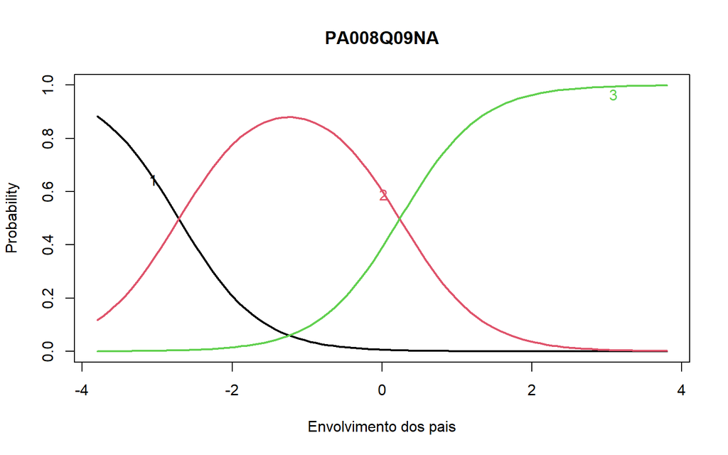

```r
#dev.off()

#png(file="figuras/TRI/envpais_PA008Q09NA.png", width=600, height=350)
plot(modEnvpais, item=9,lwd = 2,main = "PA008Q09NA", xlab="Envolvimento dos pais",ylab="Probability")
```

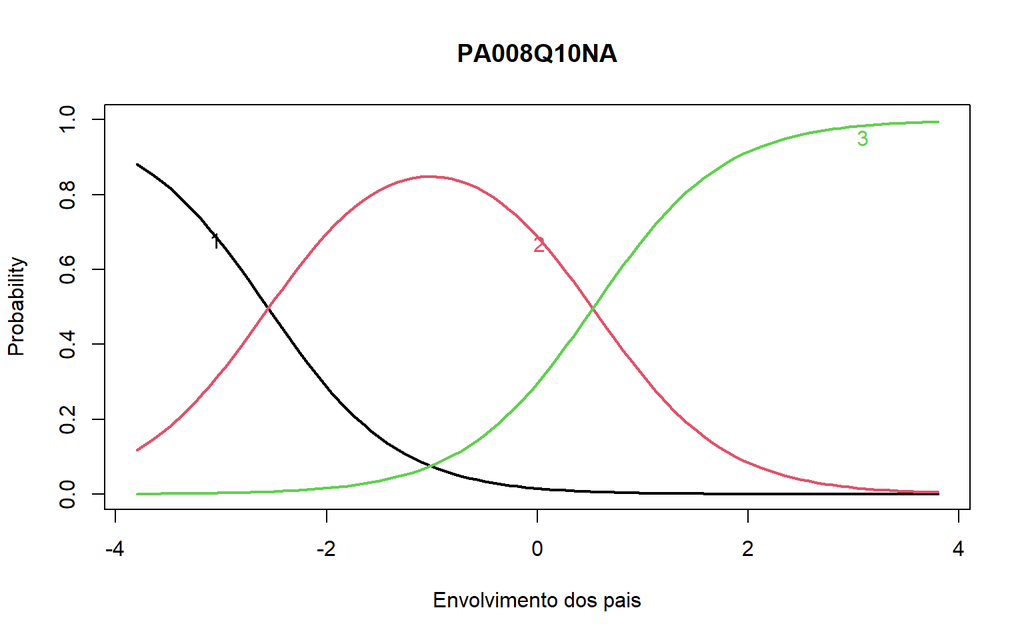

```r
#dev.off()

#png(file="figuras/TRI/envpais_PA008Q10NA.png", width=600, height=350)
plot(modEnvpais, item=10,lwd = 2,main = "PA008Q10NA", xlab="Envolvimento dos pais",ylab="Probability")
```

```r
#dev.off()



#plot(modEnvpais, item=11,lwd = 2,main = "SC064Q01TA", xlab="Envolvimento dos pais",ylab="Probability")
#plot(modEnvpais, item=12,lwd = 2,main = "SC064Q02TA", xlab="Envolvimento dos pais",ylab="Probability")
#plot(modEnvpais, item=13,lwd = 2,main = "SC064Q03TA", xlab="Envolvimento dos pais",ylab="Probability")
#plot(modEnvpais, item=14,lwd = 2,main = "SC064Q04NA", xlab="Envolvimento dos pais",ylab="Probability")
```

O codigo abaixo inclui a variavel de Envolvimento dos pais no banco de dados final, df_pisa.

```r
df_pisa = EscEnvpais$score.dat %>%
  dplyr::select(-Obs, -Exp, -se.z1) %>%
  mutate_at(vars(starts_with("ST")), factor) %>%
  mutate_at(vars(starts_with("PA")), factor) %>%
  mutate_at(vars(starts_with("SC")), factor)%>%
  rename("Envolvimento dos pais" = z1) %>%
  mutate(Envolvimento_dos_pais_Z = scale(`Envolvimento dos pais`)[,1]) %>%
  right_join(df_pisa)
```

## Envolvimento dos pais 2

Selecionando apenas as variáveis de envolvimento dos pais.

```r
Envpais = df_pisa %>%
  dplyr::select(SC064Q01TA_L,SC064Q02TA_L,SC064Q03TA_L, SC064Q04NA_L)


corenvpais= hetcor(Envpais)

#Matrix de correlacao policorica de envolvimento dos pais
corenvpais = corenvpais$correlations
```

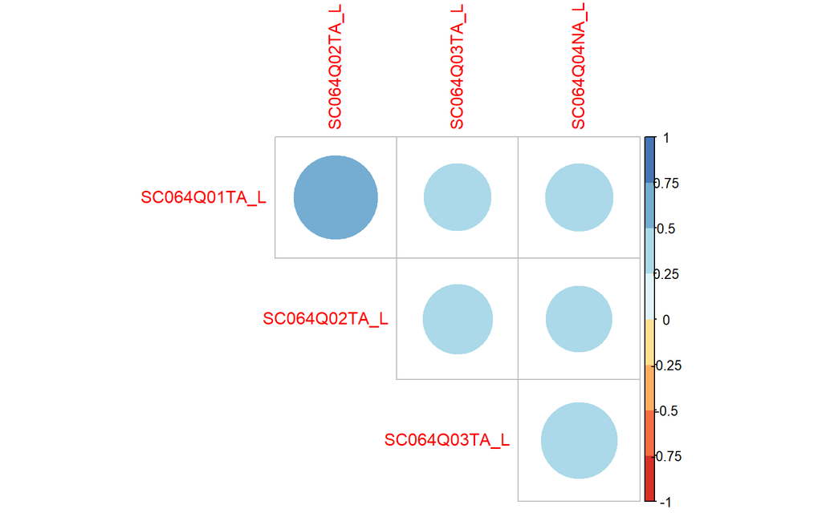

```r
#png(file="figuras/cor_policoricas/envpais2.png", width=600, height=350)


corrplot(corenvpais, type="upper", order="hclust",
         col=brewer.pal(n=8, name="RdYlBu"), diag = F)
```

```r
#dev.off()
```

```r
data.pcaenvpais <- princomp(corenvpais)
summary(data.pcaenvpais)
```

```
## Importance of components:
##                           Comp.1    Comp.2    Comp.3                  Comp.4
## Standard deviation     0.3832312 0.2585376 0.2039370 0.000000017473160325823
## Proportion of Variance 0.5752731 0.2618182 0.1629087 0.000000000000001195901
## Cumulative Proportion  0.5752731 0.8370913 1.0000000 1.000000000000000000000
```

```r
eigen(corenvpais)
```

```
## eigen() decomposition
## $values
## [1] 2.3121715 0.7631192 0.5168616 0.4078477
##
## $vectors
##            [,1]       [,2]       [,3]       [,4]
## [1,] -0.5138589  0.4920990  0.1734797  0.6809497
## [2,] -0.5180233  0.4732406 -0.1198200 -0.7023805
## [3,] -0.4889673 -0.4796201 -0.7111006  0.1587811
## [4,] -0.4780292 -0.5512227  0.6707338 -0.1332582
```

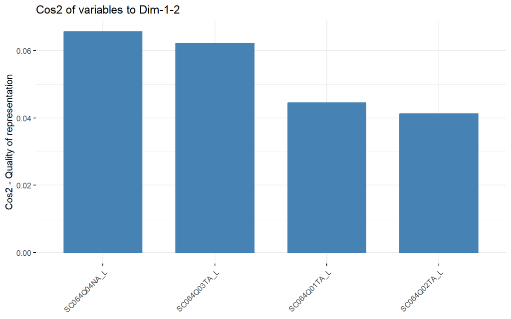

```r
#png(file="figuras/PCA/envpais21.png", width=600, height=350)

fviz_cos2(data.pcaenvpais , choice = "var", axes = 1:2)
```

```r
#dev.off()
```

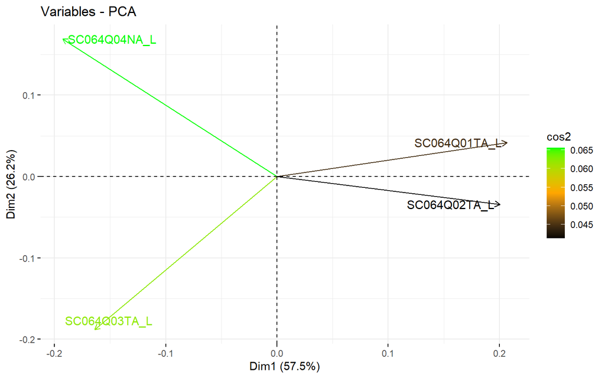

```r
#png(file="figuras/PCA/envpais22.png", width=600, height=350)

fviz_pca_var(data.pcaenvpais, col.var = "cos2",
            gradient.cols = c("black", "orange", "green"),
            repel = TRUE)
```

```r
#dev.off()
```

```r
data.pcaenvpais$scores
```

```
##                  Comp.1      Comp.2      Comp.3                    Comp.4
## SC064Q01TA_L  0.3890531  0.08907834  0.27743477  0.0000000000000013461454
## SC064Q02TA_L  0.3762431 -0.06310455 -0.28671541 -0.0000000000000014710455
## SC064Q03TA_L -0.3534553 -0.37013696  0.06439944  0.0000000000000000000000
## SC064Q04NA_L -0.4118408  0.34416316 -0.05511880  0.0000000000000002498002
```

```r
modEnvpais = grm(Envpais)
coef(modEnvpais)
```

```
##              Extrmt1 Extrmt2 Extrmt3 Dscrmn
## SC064Q01TA_L  -1.191  -0.024   0.925  1.910
## SC064Q02TA_L  -1.012  -0.060   0.936  1.964
## SC064Q03TA_L  -1.187   0.035   1.168  1.280
## SC064Q04NA_L  -1.426  -0.300   1.224  1.194
```

```r
EscEnvpais = factor.scores(modEnvpais)
```

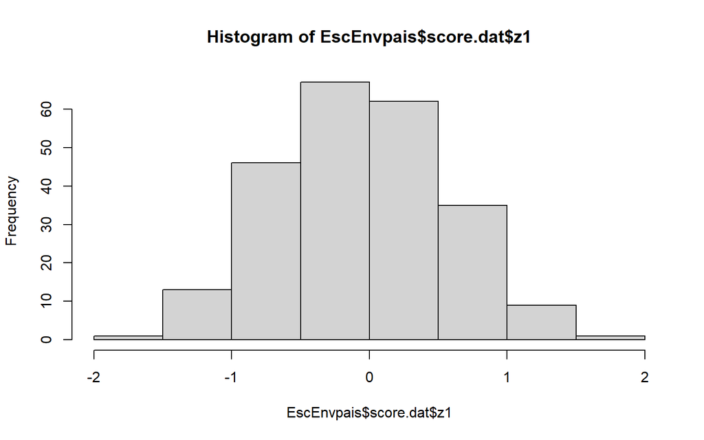

```r
hist(EscEnvpais$score.dat$z1)
```

```r
names(modEnvpais)
```

```
##  [1] "coefficients" "log.Lik"      "convergence"  "hessian"      "counts"
##  [6] "patterns"     "GH"           "max.sc"       "constrained"  "IRT.param"
## [11] "X"            "control"      "na.action"    "call"
```

```r
summary(modEnvpais)
```

```
##
## Call:
## grm(data = Envpais)
##
## Model Summary:
##    log.Lik      AIC      BIC
##  -55125.09 110282.2 110398.6
##
## Coefficients:
## $SC064Q01TA_L
##          value
## Extrmt1 -1.191
## Extrmt2 -0.024
## Extrmt3  0.925
## Dscrmn   1.910
##
## $SC064Q02TA_L
##          value
## Extrmt1 -1.012
## Extrmt2 -0.060
## Extrmt3  0.936
## Dscrmn   1.964
##
## $SC064Q03TA_L
##          value
## Extrmt1 -1.187
## Extrmt2  0.035
## Extrmt3  1.168
## Dscrmn   1.280
##
## $SC064Q04NA_L
##          value
## Extrmt1 -1.426
## Extrmt2 -0.300
## Extrmt3  1.224
## Dscrmn   1.194
##
##
## Integration:
## method: Gauss-Hermite
## quadrature points: 21
##
## Optimization:
## Convergence: 0
## max(|grad|): 0.29
## quasi-Newton: BFGS
```

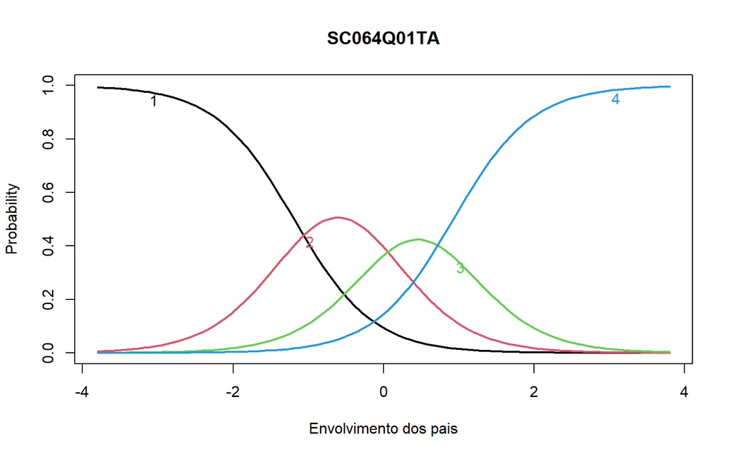

```r
#png(file="figuras/TRI/envpais2_SC064Q01TA.png", width=600, height=350)
plot(modEnvpais, item=1,lwd = 2,main = "SC064Q01TA", xlab="Envolvimento dos pais",ylab="Probability")
```

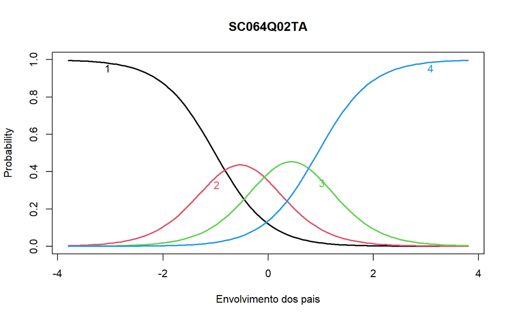

```r
#dev.off()

#png(file="figuras/TRI/envpais2_SC064Q02TA.png", width=600, height=350)
plot(modEnvpais, item=2,lwd = 2,main = "SC064Q02TA", xlab="Envolvimento dos pais",ylab="Probability")
```

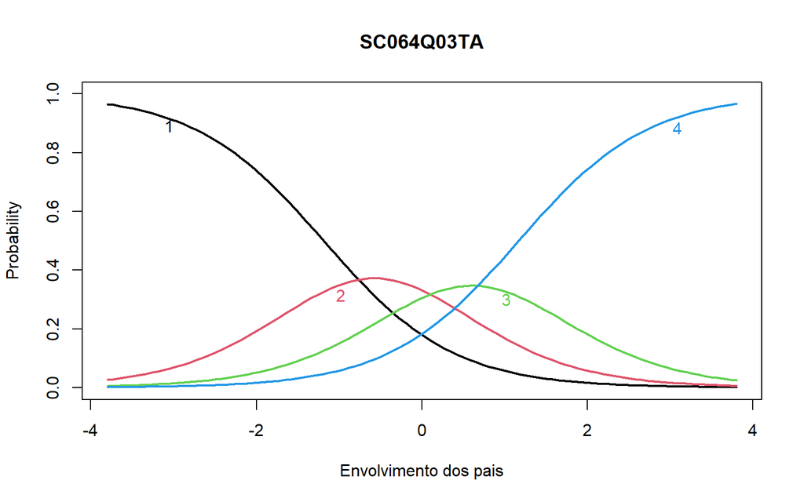

```r
#dev.off()

#png(file="figuras/TRI/envpais2_SC064Q03TA.png", width=600, height=350)
plot(modEnvpais, item=3,lwd = 2,main = "SC064Q03TA", xlab="Envolvimento dos pais",ylab="Probability")
```

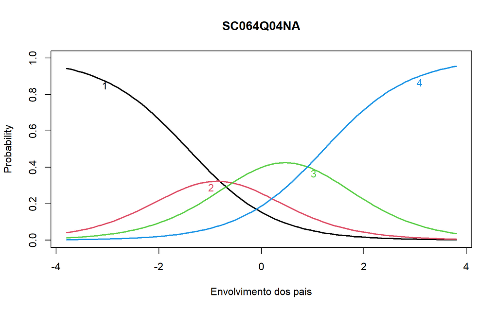

```r
#dev.off()

#png(file="figuras/TRI/envpais2_SC064Q04NA.png", width=600, height=350)
plot(modEnvpais, item=4,lwd = 2,main = "SC064Q04NA", xlab="Envolvimento dos pais",ylab="Probability")
```

```r
#dev.off()
```

O indicador de repetencia foi construído de modo a se obter a frequencia total de vezes que os alunos foram reprovados. Sendo 0 atrubuído ao aluno que nunca foi reprovado e 6 para os que reprovaram pelo menos 6 vezes.

```r
df_pisa = df_pisa %>%
  mutate(Repetencia = as.numeric(ST127Q01TA)+ as.numeric(ST127Q02TA)+ as.numeric(ST127Q03TA) - 3) %>%
  mutate(Repetencia_Z =  scale(Repetencia))
```

```r
df_pisa %>%
  group_by(Repetencia) %>%
  count()
```

```
## # A tibble: 7 × 2
## # Groups:   Repetencia [7]
##   Repetencia     n
##        <dbl> <int>
## 1          0  7384
## 2          1  1841
## 3          2  1014
## 4          3   324
## 5          4   120
## 6          5     3
## 7          6     5
```

# Variávies para Equações estruturais

Selecionando os indicadores criados para realizar a seleção das variáveis.

```r
#= scale(Nota)[,1]

df_final = df_pisa %>%
  transmute(id_escola, id_aluno, rede, administracao, regiao, sexo, W_FSTUWT,
            Bullying, Bullying_Z,
            indisciplina, indisciplina_Z,
            faltaeatraso, faltaeatraso_Z,
            Entusiasmo, Entusiasmo_Z,
            apoio_doscente = `Apoio docente`, apoio_doscente_Z = Apoio_docente_Z,
            compprof = `Comportamento professor`,  compprof_Z = Comportamento_professor_Z,
            cooperacao = `Cooperação e competição`, cooperacao_Z = `Cooperacao_competicao_Z`,
            competicao = `Competição`, competicao_Z = `Competicao_Z`,
            snt_prtc = `Sentimento de pertencimento`,  snt_prtc_Z = `Sentimento_pertencimento_Z`,
            envPais = `Envolvimento dos pais`, envPais = `Envolvimento_dos_pais_Z`,
            Repetencia, Repetencia_Z,
            Nota, Nota_Z = scale(Nota)[,1],
            NSE, NSE_Z = scale(NSE)[,1])
```

```r
df_final = df_final %>%
  group_by(id_escola) %>%
  mutate(NSE_medio = mean(NSE),
         NSE_medio_Z = mean(NSE_Z),
         Entusiasmo_medio = mean(Entusiasmo),
         Entusiasmo_medio_Z = mean(Entusiasmo_Z),
         snt_prtc_medio = mean(snt_prtc),
         snt_prtc_medio_Z = mean(snt_prtc_Z),
         apoio_doscente_medio = mean(apoio_doscente),
         apoio_doscente_medio_Z = mean(apoio_doscente_Z),
         sexo_propF = mean(ifelse(sexo=="F", 1, 0)),
         Bullying_medio = mean(Bullying),
         Bullying_medio_Z = mean(Bullying_Z),
         faltaeatraso_medio = mean(faltaeatraso),
         faltaeatraso_medio_Z = mean(faltaeatraso_Z),
         indisciplina_medio = mean(indisciplina),
         indisciplina_medio_Z = mean(indisciplina_Z),
         Repetencia_medio = mean(Repetencia),
         Repetencia_medio_Z = mean(Repetencia_Z))
```

# Step Wise

Foi criada uma regressão linear para a nota no nível escola, a fim de auxiliar na seleção das variáveis.

```r
teste = df_final %>%
  mutate(NSE_medio = mean(NSE),
         Entusiasmo_medio = mean(Entusiasmo),
         snt_prtc_medio = mean(snt_prtc),
         apoio_doscente_medio = mean(apoio_doscente),
         sexo_propF = mean(ifelse(sexo=="F", 1, 0)),
         Bullying_medio = mean(Bullying),
         faltaeatraso_medio = mean(faltaeatraso),
         indisciplina_medio = mean(indisciplina),
         Repetencia_medio = mean(Repetencia),
         Nota = mean(Nota),
         compprof = mean(compprof),
         cooperacao = mean(cooperacao),
         competicao = mean(competicao),
         envPais = mean(envPais))
```

## Seleção Setpwise com todas as variáveis

```r
fit = lm(Nota~., teste)

summary(fit)
```

```
##
## Call:
## lm(formula = Nota ~ ., data = teste)
##
## Residuals:
##      Min       1Q   Median       3Q      Max
## -114.607  -17.090    0.292   17.414  132.181
##
## Coefficients: (17 not defined because of singularities)
##                               Estimate      Std. Error t value
## (Intercept)            -28564.00185354  11360.08203174  -2.514
## id_escola                   0.00384019      0.00149456   2.569
## id_aluno                   -0.00001882      0.00005167  -0.364
## redePública               -21.67597390      1.26269492 -17.166
## administracaoFederal       40.35281741      1.78797798  22.569
## administracaoMunicipal      4.43709152      1.30183843   3.408
## administracaoPrivada                NA              NA      NA
## regiaoNordeste             -6.10420631      0.85902256  -7.106
## regiaoNorte               -11.08327852      1.09277517 -10.142
## regiaoSul                   1.41582258      1.73269047   0.817
## regiaoSuldeste              0.94803576      0.78815009   1.203
## sexoM                       1.75133099      0.54966122   3.186
## W_FSTUWT                   -0.02366889      0.00316407  -7.481
## Bullying                    0.47240994      0.38031519   1.242
## Bullying_Z                          NA              NA      NA
## indisciplina                0.72537202      0.33839889   2.144
## indisciplina_Z                      NA              NA      NA
## faltaeatraso                1.31579180      0.38329234   3.433
## faltaeatraso_Z                      NA              NA      NA
## Entusiasmo                 -0.63503191      0.40101604  -1.584
## Entusiasmo_Z                        NA              NA      NA
## apoio_doscente              0.68733378      0.38683079   1.777
## apoio_doscente_Z                    NA              NA      NA
## compprof                    1.49271546      1.60795477   0.928
## compprof_Z                 -0.39483430      1.38371640  -0.285
## cooperacao                  2.99330542      1.17394819   2.550
## cooperacao_Z                0.53975102      0.32506858   1.660
## competicao                  8.99068347      1.15758239   7.767
## competicao_Z               -0.07421658      0.25642474  -0.289
## snt_prtc                   -0.76120022      0.32918694  -2.312
```

[output cut: 70 more lines]

```
## sexo_propF              0.00000000003790160 ***
## Bullying_medio                     0.000699 ***
## Bullying_medio_Z                         NA
## faltaeatraso_medio     < 0.0000000000000002 ***
## faltaeatraso_medio_Z                     NA
## indisciplina_medio     < 0.0000000000000002 ***
## indisciplina_medio_Z                     NA
## Repetencia_medio       < 0.0000000000000002 ***
## Repetencia_medio_Z                       NA
## ---
## Signif. codes:  0 '***' 0.001 '**' 0.01 '*' 0.05 '.' 0.1 ' ' 1
##
## Residual standard error: 27.03 on 10654 degrees of freedom
## Multiple R-squared:  0.8337, Adjusted R-squared:  0.8332
## F-statistic:  1484 on 36 and 10654 DF,  p-value: < 0.00000000000000022
```

```r
library(MASS)
```

```r
step = stepAIC(fit)
```

```
## Start:  AIC=70531.47
## Nota ~ id_escola + id_aluno + rede + administracao + regiao +
##     sexo + W_FSTUWT + Bullying + Bullying_Z + indisciplina +
##     indisciplina_Z + faltaeatraso + faltaeatraso_Z + Entusiasmo +
##     Entusiasmo_Z + apoio_doscente + apoio_doscente_Z + compprof +
##     compprof_Z + cooperacao + cooperacao_Z + competicao + competicao_Z +
##     snt_prtc + snt_prtc_Z + envPais + Repetencia + Repetencia_Z +
##     Nota_Z + NSE + NSE_Z + NSE_medio + NSE_medio_Z + Entusiasmo_medio +
##     Entusiasmo_medio_Z + snt_prtc_medio + snt_prtc_medio_Z +
##     apoio_doscente_medio + apoio_doscente_medio_Z + sexo_propF +
##     Bullying_medio + Bullying_medio_Z + faltaeatraso_medio +
##     faltaeatraso_medio_Z + indisciplina_medio + indisciplina_medio_Z +
##     Repetencia_medio + Repetencia_medio_Z
##
##
## Step:  AIC=70531.47
## Nota ~ id_escola + id_aluno + rede + administracao + regiao +
##     sexo + W_FSTUWT + Bullying + Bullying_Z + indisciplina +
##     indisciplina_Z + faltaeatraso + faltaeatraso_Z + Entusiasmo +
##     Entusiasmo_Z + apoio_doscente + apoio_doscente_Z + compprof +
##     compprof_Z + cooperacao + cooperacao_Z + competicao + competicao_Z +
##     snt_prtc + snt_prtc_Z + envPais + Repetencia + Repetencia_Z +
##     Nota_Z + NSE + NSE_Z + NSE_medio + NSE_medio_Z + Entusiasmo_medio +
##     Entusiasmo_medio_Z + snt_prtc_medio + snt_prtc_medio_Z +
##     apoio_doscente_medio + apoio_doscente_medio_Z + sexo_propF +
##     Bullying_medio + Bullying_medio_Z + faltaeatraso_medio +
##     faltaeatraso_medio_Z + indisciplina_medio + indisciplina_medio_Z +
##     Repetencia_medio
##
##
## Step:  AIC=70531.47
## Nota ~ id_escola + id_aluno + rede + administracao + regiao +
##     sexo + W_FSTUWT + Bullying + Bullying_Z + indisciplina +
##     indisciplina_Z + faltaeatraso + faltaeatraso_Z + Entusiasmo +
##     Entusiasmo_Z + apoio_doscente + apoio_doscente_Z + compprof +
##     compprof_Z + cooperacao + cooperacao_Z + competicao + competicao_Z +
##     snt_prtc + snt_prtc_Z + envPais + Repetencia + Repetencia_Z +
##     Nota_Z + NSE + NSE_Z + NSE_medio + NSE_medio_Z + Entusiasmo_medio +
##     Entusiasmo_medio_Z + snt_prtc_medio + snt_prtc_medio_Z +
##     apoio_doscente_medio + apoio_doscente_medio_Z + sexo_propF +
```

[output cut: 358 more lines]

```
## - sexo_propF            1     32301 7817066 70568
## - apoio_doscente_medio  1     35494 7820259 70572
## - W_FSTUWT              1     40893 7825658 70579
## - competicao            1     46726 7831491 70587
## - Repetencia            1     66154 7850920 70614
## - Entusiasmo_medio      1     87090 7871856 70642
## - snt_prtc_medio        1    119423 7904188 70686
## - regiao                4    143887 7928653 70713
## - indisciplina_medio    1    265134 8049900 70881
## - faltaeatraso_medio    1    296018 8080784 70922
## - envPais               1    375159 8159924 71026
## - administracao         3    481866 8266631 71161
## - Repetencia_medio      1    820836 8605601 71595
## - NSE_medio             1   1039593 8824359 71863
## - Nota_Z                1   1384412 9169178 72273
```

## Modelo final Stepwise

Resultado das variáveis selecionadas que formam um modelo mais parcimonioso no nível da escola.

```r
summary(step)
```

```
##
## Call:
## lm(formula = Nota ~ id_escola + administracao + regiao + sexo +
##     W_FSTUWT + indisciplina + faltaeatraso + Entusiasmo + apoio_doscente +
##     compprof + cooperacao + cooperacao_Z + competicao + snt_prtc +
##     envPais + Repetencia + Nota_Z + NSE + NSE_medio + Entusiasmo_medio +
##     snt_prtc_medio + apoio_doscente_medio + sexo_propF + Bullying_medio +
##     faltaeatraso_medio + indisciplina_medio + Repetencia_medio,
##     data = teste)
##
## Residuals:
##      Min       1Q   Median       3Q      Max
## -114.603  -17.084    0.297   17.317  132.165
##
## Coefficients:
##                             Estimate    Std. Error t value             Pr(>|t|)
## (Intercept)            -28670.849359  11356.804520  -2.525             0.011599
## id_escola                   0.003833      0.001494   2.565             0.010335
## administracaoFederal       40.355682      1.787760  22.573 < 0.0000000000000002
## administracaoMunicipal      4.426265      1.301323   3.401             0.000673
## administracaoPrivada       21.676552      1.262533  17.169 < 0.0000000000000002
## regiaoNordeste             -6.101481      0.858871  -7.104  0.00000000000128867
## regiaoNorte               -11.083363      1.092651 -10.144 < 0.0000000000000002
## regiaoSul                   1.420677      1.732466   0.820             0.412216
## regiaoSuldeste              0.948887      0.788066   1.204             0.228589
## sexoM                       1.812727      0.546171   3.319             0.000907
## W_FSTUWT                   -0.023671      0.003164  -7.482  0.00000000000007877
## indisciplina                0.759028      0.335670   2.261             0.023765
## faltaeatraso                1.388299      0.377853   3.674             0.000240
## Entusiasmo                 -0.650700      0.400628  -1.624             0.104362
## apoio_doscente              0.677866      0.386699   1.753             0.079638
## compprof                    1.044095      0.332387   3.141             0.001687
## cooperacao                  2.985064      1.172981   2.545             0.010946
## cooperacao_Z                0.545655      0.322273   1.693             0.090457
## competicao                  8.900486      1.112811   7.998  0.00000000000000139
## snt_prtc                   -0.854439      0.320994  -2.662             0.007783
## envPais                   -21.474825      0.947561 -22.663 < 0.0000000000000002
## Repetencia                  3.938008      0.413793   9.517 < 0.0000000000000002
## Nota_Z                     14.906424      0.342394  43.536 < 0.0000000000000002
## NSE                        -0.904752      0.283050  -3.196             0.001395
```

[output cut: 34 more lines]

```
## NSE_medio              ***
## Entusiasmo_medio       ***
## snt_prtc_medio         ***
## apoio_doscente_medio   ***
## sexo_propF             ***
## Bullying_medio         **
## faltaeatraso_medio     ***
## indisciplina_medio     ***
## Repetencia_medio       ***
## ---
## Signif. codes:  0 '***' 0.001 '**' 0.01 '*' 0.05 '.' 0.1 ' ' 1
##
## Residual standard error: 27.03 on 10658 degrees of freedom
## Multiple R-squared:  0.8337, Adjusted R-squared:  0.8332
## F-statistic:  1670 on 32 and 10658 DF,  p-value: < 0.00000000000000022
```

# Descritivas dos indicadores

```r
vars='Bullying_medio_Z  + faltaeatraso_medio_Z + indisciplina_medio_Z+
  Nota ~ 1+ Bullying_Z + indisciplina_Z + faltaeatraso_Z + NSE_medio_Z+ NSE_Z+ Entusiasmo_medio_Z +Entusiasmo_Z +  snt_prtc_medio_Z+ snt_prtc_Z+ sexo_propF + Repetencia_Z + Repetencia_medio_Z+
  Bullying_Z ~  1 + NSE_Z+ Entusiasmo_medio_Z +Entusiasmo_Z +  snt_prtc_medio_Z+ snt_prtc_Z+ sexo_propF  + Repetencia_Z + Repetencia_medio_Z+
  indisciplina_Z ~ 1 + NSE_Z+ Entusiasmo_medio_Z +Entusiasmo_Z +  snt_prtc_medio_Z+ snt_prtc_Z+ sexo_propF + Repetencia_Z + Repetencia_medio_Z+
  faltaeatraso_Z ~ 1 + NSE_Z+ Entusiasmo_medio_Z +Entusiasmo_Z +  snt_prtc_medio_Z+ snt_prtc_Z+ sexo_propF + Repetencia_Z + Repetencia_medio_Z'

library(tidyverse)
library(stringr)

vars = vars %>%
  str_squish() %>%
  str_remove_all(" ") %>%
  str_split("\\+") %>%
  unlist() %>%
  unique() %>%
 str_remove("~1")


medias =df_final %>%
  ungroup() %>%
  summarise(across(vars, .fns = mean))

Dps = df_final %>%
  ungroup() %>%
  summarise(across(vars, .fns = sd))


minimos = df_final %>%
  ungroup() %>%
  summarise(across(vars, .fns = ~min(.x) ))

maximos = df_final %>%
  ungroup() %>%
  summarise(across(vars, .fns = ~max(.x) ))
```

```r
medias
```

```
## # A tibble: 1 × 16
##   Bullying_medio_Z faltaeatraso_medio_Z indisciplina_medio_Z  Nota Bullying_Z
##              <dbl>                <dbl>                <dbl> <dbl>      <dbl>
## 1            -2.67                -1.14               -0.256  416.      -2.67
## # ℹ 11 more variables: indisciplina_Z <dbl>, faltaeatraso_Z <dbl>,
## #   NSE_medio_Z <dbl>, NSE_Z <dbl>, Entusiasmo_medio_Z <dbl>,
## #   Entusiasmo_Z <dbl>, snt_prtc_medio_Z <dbl>, snt_prtc_Z <dbl>,
## #   sexo_propF <dbl>, Repetencia_Z <dbl>, Repetencia_medio_Z <dbl>
```

```r
Dps
```

```
## # A tibble: 1 × 16
##   Bullying_medio_Z faltaeatraso_medio_Z indisciplina_medio_Z  Nota Bullying_Z
##              <dbl>                <dbl>                <dbl> <dbl>      <dbl>
## 1            0.519                0.322                0.532  98.5       1.68
## # ℹ 11 more variables: indisciplina_Z <dbl>, faltaeatraso_Z <dbl>,
## #   NSE_medio_Z <dbl>, NSE_Z <dbl>, Entusiasmo_medio_Z <dbl>,
## #   Entusiasmo_Z <dbl>, snt_prtc_medio_Z <dbl>, snt_prtc_Z <dbl>,
## #   sexo_propF <dbl>, Repetencia_Z <dbl>, Repetencia_medio_Z <dbl>
```

```r
minimos
```

```
## # A tibble: 1 × 16
##   Bullying_medio_Z faltaeatraso_medio_Z indisciplina_medio_Z  Nota Bullying_Z
##              <dbl>                <dbl>                <dbl> <dbl>      <dbl>
## 1            -4.04                -2.16                -2.86  119.      -4.04
## # ℹ 11 more variables: indisciplina_Z <dbl>, faltaeatraso_Z <dbl>,
## #   NSE_medio_Z <dbl>, NSE_Z <dbl>, Entusiasmo_medio_Z <dbl>,
## #   Entusiasmo_Z <dbl>, snt_prtc_medio_Z <dbl>, snt_prtc_Z <dbl>,
## #   sexo_propF <dbl>, Repetencia_Z <dbl>, Repetencia_medio_Z <dbl>
```

```r
maximos
```

```
## # A tibble: 1 × 16
##   Bullying_medio_Z faltaeatraso_medio_Z indisciplina_medio_Z  Nota Bullying_Z
##              <dbl>                <dbl>                <dbl> <dbl>      <dbl>
## 1            0.871                0.664                 1.34  770.       3.53
## # ℹ 11 more variables: indisciplina_Z <dbl>, faltaeatraso_Z <dbl>,
## #   NSE_medio_Z <dbl>, NSE_Z <dbl>, Entusiasmo_medio_Z <dbl>,
## #   Entusiasmo_Z <dbl>, snt_prtc_medio_Z <dbl>, snt_prtc_Z <dbl>,
## #   sexo_propF <dbl>, Repetencia_Z <dbl>, Repetencia_medio_Z <dbl>
```

# Modelos de equações estruturais

## Não padronizado

```r
library(lavaan)


model <- '
  # measurement model
    Disruptivo_medio =~ Bullying_medio  + faltaeatraso_medio + indisciplina_medio
  # regressions
  Nota ~ 1+ Bullying + indisciplina + faltaeatraso + Disruptivo_medio + NSE_medio+ NSE+ Entusiasmo_medio +Entusiasmo +  snt_prtc_medio+ snt_prtc+ sexo_propF +sexo + Repetencia + Repetencia_medio
  Bullying ~  1 + NSE+ Entusiasmo_medio +Entusiasmo +  snt_prtc_medio+ snt_prtc+ sexo_propF +sexo + Repetencia + Repetencia_medio
  indisciplina ~ 1 + NSE+ Entusiasmo_medio +Entusiasmo +  snt_prtc_medio+ snt_prtc+ sexo_propF +sexo  + Repetencia + Repetencia_medio
  faltaeatraso ~ 1 + NSE+ Entusiasmo_medio +Entusiasmo +  snt_prtc_medio+ snt_prtc+ sexo_propF +sexo  + Repetencia + Repetencia_medio
  # residual correlations
'
```

```r
fit <- sem(model, data=df_final, cluster = "id_escola")

summary(fit, fit.measures = TRUE, standardized=TRUE)
```

```
## lavaan 0.6.16 ended normally after 295 iterations
##
##   Estimator                                         ML
##   Optimization method                           NLMINB
##   Number of model parameters                        58
##
##   Number of observations                         10691
##   Number of clusters [id_escola]                   597
##
## Model Test User Model:
##                                                Standard      Scaled
##   Test Statistic                              10450.277    1797.107
##   Degrees of freedom                                 47          47
##   P-value (Chi-square)                            0.000       0.000
##   Scaling correction factor                                   5.815
##     Yuan-Bentler correction (Mplus variant)
##   Observed information based on                      H1
##
## Model Test Baseline Model:
##
##   Test statistic                             20667.595    4884.396
##   Degrees of freedom                                91          91
##   P-value                                        0.000       0.000
##   Scaling correction factor                                  4.231
##
## User Model versus Baseline Model:
##
##   Comparative Fit Index (CFI)                    0.494       0.635
##   Tucker-Lewis Index (TLI)                       0.021       0.293
##
##   Robust Comparative Fit Index (CFI)                         0.498
##   Robust Tucker-Lewis Index (TLI)                            0.029
##
## Loglikelihood and Information Criteria:
##
##   Loglikelihood user model (H0)            -102522.374 -102522.374
##   Scaling correction factor                                  4.388
##       for the MLR correction
##   Loglikelihood unrestricted model (H1)     -97297.236  -97297.236
##   Scaling correction factor                                  5.027
```

[output cut: 91 more lines]

```
##    .Bullying_medio    0.217    0.010   21.900    0.000    0.217    0.910
##    .faltaeatras_md    0.081    0.011    7.463    0.000    0.081    0.311
##    .indisciplin_md    0.003    0.015    0.186    0.852    0.003    0.008
##     Disruptivo_med    0.000                               0.000    0.000
##
## Variances:
##                    Estimate  Std.Err  z-value  P(>|z|)   Std.lv  Std.all
##    .Bullying_medio    0.043    0.003   12.956    0.000    0.043    0.763
##    .faltaeatras_md    0.041    0.005    8.581    0.000    0.041    0.612
##    .indisciplin_md    0.100    0.009   11.084    0.000    0.100    0.758
##    .Nota           5763.805  111.754   51.576    0.000 5763.805    0.631
##    .Bullying          0.546    0.010   52.229    0.000    0.546    0.914
##    .indisciplina      0.719    0.012   59.408    0.000    0.719    0.904
##    .faltaeatraso      0.541    0.009   62.020    0.000    0.541    0.959
##     Disruptivo_med    0.013    0.003    4.440    0.000    1.000    1.000
```

```r
library(lavaanPlot)
lavaanPlot(model = fit, node_options = list(shape = "box", fontname = "Helvetica"), edge_options = list(color = "grey"), coefs = TRUE)
```

# Padronizado mas com a nota na escala original

Útil para analisar os efeitos na escala real da nota

```r
library(lavaan)


model <- '
  # measurement model
    Disruptivo_medio =~ Bullying_medio_Z  + faltaeatraso_medio_Z + indisciplina_medio_Z
  # regressions
  Nota ~ 1+ Bullying_Z + indisciplina_Z + faltaeatraso_Z + Disruptivo_medio + NSE_medio_Z+ NSE_Z+ Entusiasmo_medio_Z +Entusiasmo_Z +  snt_prtc_medio_Z+ snt_prtc_Z+ sexo_propF +sexo + Repetencia_Z + Repetencia_medio_Z
  Bullying_Z ~  1 + NSE_Z+ Entusiasmo_medio_Z +Entusiasmo_Z +  snt_prtc_medio_Z+ snt_prtc_Z+ sexo_propF +sexo + Repetencia_Z + Repetencia_medio_Z
  indisciplina_Z ~ 1 + NSE_Z+ Entusiasmo_medio_Z +Entusiasmo_Z +  snt_prtc_medio_Z+ snt_prtc_Z+ sexo_propF +sexo + Repetencia_Z + Repetencia_medio_Z
  faltaeatraso_Z ~ 1 + NSE_Z+ Entusiasmo_medio_Z +Entusiasmo_Z +  snt_prtc_medio_Z+ snt_prtc_Z+ sexo_propF +sexo + Repetencia_Z + Repetencia_medio_Z
  # residual correlations
'
```

```r
fit <- sem(model, data=df_final, cluster = "id_escola")

summary(fit, fit.measures = TRUE, standardized=TRUE)
```

```
## lavaan 0.6.16 ended normally after 269 iterations
##
##   Estimator                                         ML
##   Optimization method                           NLMINB
##   Number of model parameters                        58
##
##   Number of observations                         10691
##   Number of clusters [id_escola]                   597
##
## Model Test User Model:
##                                                Standard      Scaled
##   Test Statistic                              10450.311    1797.086
##   Degrees of freedom                                 47          47
##   P-value (Chi-square)                            0.000       0.000
##   Scaling correction factor                                   5.815
##     Yuan-Bentler correction (Mplus variant)
##   Observed information based on                      H1
##
## Model Test Baseline Model:
##
##   Test statistic                             20667.595    4884.396
##   Degrees of freedom                                91          91
##   P-value                                        0.000       0.000
##   Scaling correction factor                                  4.231
##
## User Model versus Baseline Model:
##
##   Comparative Fit Index (CFI)                    0.494       0.635
##   Tucker-Lewis Index (TLI)                       0.021       0.293
##
##   Robust Comparative Fit Index (CFI)                         0.498
##   Robust Tucker-Lewis Index (TLI)                            0.029
##
## Loglikelihood and Information Criteria:
##
##   Loglikelihood user model (H0)            -131940.198 -131940.198
##   Scaling correction factor                                  4.388
##       for the MLR correction
##   Loglikelihood unrestricted model (H1)    -126715.043 -126715.043
##   Scaling correction factor                                  5.027
```

[output cut: 91 more lines]

```
##    .Bullying_med_Z   -2.674    0.022 -123.893    0.000   -2.674   -5.150
##    .faltaetrs_md_Z   -1.140    0.013  -85.075    0.000   -1.140   -3.546
##    .indiscpln_md_Z   -0.256    0.023  -11.299    0.000   -0.256   -0.480
##     Disruptivo_med    0.000                               0.000    0.000
##
## Variances:
##                    Estimate  Std.Err  z-value  P(>|z|)   Std.lv  Std.all
##    .Bullying_med_Z    0.206    0.016   12.961    0.000    0.206    0.763
##    .faltaetrs_md_Z    0.063    0.007    8.585    0.000    0.063    0.612
##    .indiscpln_md_Z    0.215    0.019   11.081    0.000    0.215    0.758
##    .Nota           5763.309  111.800   51.550    0.000 5763.309    0.631
##    .Bullying_Z        2.593    0.050   52.229    0.000    2.593    0.914
##    .indisciplina_Z    1.540    0.026   59.408    0.000    1.540    0.904
##    .faltaeatraso_Z    0.833    0.013   62.020    0.000    0.833    0.959
##     Disruptivo_med    0.064    0.014    4.440    0.000    1.000    1.000
```

```r
library(lavaanPlot)
lavaanPlot(model = fit, node_options = list(shape = "box", fontname = "Helvetica"), edge_options = list(color = "grey"), coefs = TRUE)
```